# Credit Risk Modeling

## Introduction

Credit Risk Modeling is a statistical approach used to estimate the likelihood that a borrower will default on their loan or credit obligation. It's crucial for financial institutions to assess the risk associated with lending to minimize potential losses. This model helps in decision-making processes such as loan approvals, setting interest rates, and managing credit portfolios.

## Problem Statement

The goal of this project is to build a machine learning model that predicts the probability of loan defaults for individuals based on their historical financial behavior and credit data.

## Objective

Building a model to classify borrowers into risk categories (low, medium, high). Identifying the key factors contributing to the likelihood of default. Deploying the model for practical usage by financial institutions.

## Scope

Use of historical credit data (such as age, income, loan type, repayment history, etc.). Implementation of Machine Learning techniques like Logistic Regression, Random Forest, XGBoost. Performance evaluation using metrics such as accuracy, precision, recall, and AUC.

```python
import pandas as pd
import numpy as np
from matplotlib import pyplot as plt
import seaborn as sns
from sklearn.model_selection import train_test_split

pd.set_option('display.float_format', lambda x: '{:.2f}'.format(x))
np.set_printoptions(suppress=True)
```

### Load Data

```python
df_customers = pd.read_csv("customers.csv")
df_loans = pd.read_csv("loans.csv")
df_bureau = pd.read_csv("bureau_data.csv")
```

```python
df_customers.shape, df_loans.shape, df_bureau.shape
```

```
((50000, 12), (50000, 15), (50000, 8))
```

```python
df_customers.head(3)
```

|  | cust_id | age | gender | marital_status | employment_status | income | number_of_dependants | residence_type | years_at_current_address | city | state | zipcode |
| --- | --- | --- | --- | --- | --- | --- | --- | --- | --- | --- | --- | --- |
| 0 | C00001 | 44 | M | Married | Self-Employed | 2586000 | 3 | Owned | 27 | Delhi | Delhi | 110001 |
| 1 | C00002 | 38 | M | Married | Salaried | 1206000 | 3 | Owned | 4 | Chennai | Tamil Nadu | 600001 |
| 2 | C00003 | 46 | F | Married | Self-Employed | 2878000 | 3 | Owned | 24 | Kolkata | West Bengal | 700001 |

```python
df_loans.head(3)
```

|  | loan_id | cust_id | loan_purpose | loan_type | sanction_amount | loan_amount | processing_fee | gst | net_disbursement | loan_tenure_months | principal_outstanding | bank_balance_at_application | disbursal_date | installment_start_dt | default |
| --- | --- | --- | --- | --- | --- | --- | --- | --- | --- | --- | --- | --- | --- | --- | --- |
| 0 | L00001 | C00001 | Auto | Secured | 3004000 | 2467000 | 49340.00 | 444060 | 1973600 | 33 | 1630408 | 873386 | 2019-07-24 | 2019-08-10 | False |
| 1 | L00002 | C00002 | Home | Secured | 4161000 | 3883000 | 77660.00 | 698940 | 3106400 | 30 | 709309 | 464100 | 2019-07-24 | 2019-08-15 | False |
| 2 | L00003 | C00003 | Personal | Unsecured | 2401000 | 2170000 | 43400.00 | 390600 | 1736000 | 21 | 1562399 | 1476042 | 2019-07-24 | 2019-08-21 | False |

```python
df_bureau.head(3)
```

|  | cust_id | number_of_open_accounts | number_of_closed_accounts | total_loan_months | delinquent_months | total_dpd | enquiry_count | credit_utilization_ratio |
| --- | --- | --- | --- | --- | --- | --- | --- | --- |
| 0 | C00001 | 1 | 1 | 42 | 0 | 0 | 3 | 7 |
| 1 | C00002 | 3 | 1 | 96 | 12 | 60 | 5 | 4 |
| 2 | C00003 | 2 | 1 | 82 | 24 | 147 | 6 | 58 |

```python
df = pd.merge(df_customers, df_loans, on='cust_id')
df.head(3)
```

|  | cust_id | age | gender | marital_status | employment_status | income | number_of_dependants | residence_type | years_at_current_address | city | ... | loan_amount | processing_fee | gst | net_disbursement | loan_tenure_months | principal_outstanding | bank_balance_at_application | disbursal_date | installment_start_dt | default |
| --- | --- | --- | --- | --- | --- | --- | --- | --- | --- | --- | --- | --- | --- | --- | --- | --- | --- | --- | --- | --- | --- |
| 0 | C00001 | 44 | M | Married | Self-Employed | 2586000 | 3 | Owned | 27 | Delhi | ... | 2467000 | 49340.00 | 444060 | 1973600 | 33 | 1630408 | 873386 | 2019-07-24 | 2019-08-10 | False |
| 1 | C00002 | 38 | M | Married | Salaried | 1206000 | 3 | Owned | 4 | Chennai | ... | 3883000 | 77660.00 | 698940 | 3106400 | 30 | 709309 | 464100 | 2019-07-24 | 2019-08-15 | False |
| 2 | C00003 | 46 | F | Married | Self-Employed | 2878000 | 3 | Owned | 24 | Kolkata | ... | 2170000 | 43400.00 | 390600 | 1736000 | 21 | 1562399 | 1476042 | 2019-07-24 | 2019-08-21 | False |

3 rows × 26 columns

```python
df = pd.merge(df, df_bureau, on='cust_id')
df.head(3)
```

|  | cust_id | age | gender | marital_status | employment_status | income | number_of_dependants | residence_type | years_at_current_address | city | ... | disbursal_date | installment_start_dt | default | number_of_open_accounts | number_of_closed_accounts | total_loan_months | delinquent_months | total_dpd | enquiry_count | credit_utilization_ratio |
| --- | --- | --- | --- | --- | --- | --- | --- | --- | --- | --- | --- | --- | --- | --- | --- | --- | --- | --- | --- | --- | --- |
| 0 | C00001 | 44 | M | Married | Self-Employed | 2586000 | 3 | Owned | 27 | Delhi | ... | 2019-07-24 | 2019-08-10 | False | 1 | 1 | 42 | 0 | 0 | 3 | 7 |
| 1 | C00002 | 38 | M | Married | Salaried | 1206000 | 3 | Owned | 4 | Chennai | ... | 2019-07-24 | 2019-08-15 | False | 3 | 1 | 96 | 12 | 60 | 5 | 4 |
| 2 | C00003 | 46 | F | Married | Self-Employed | 2878000 | 3 | Owned | 24 | Kolkata | ... | 2019-07-24 | 2019-08-21 | False | 2 | 1 | 82 | 24 | 147 | 6 | 58 |

3 rows × 33 columns

```python
df.info()
```

```
<class 'pandas.core.frame.DataFrame'>
RangeIndex: 50000 entries, 0 to 49999
Data columns (total 33 columns):
 #   Column                       Non-Null Count  Dtype
---  ------                       --------------  -----
 0   cust_id                      50000 non-null  object
 1   age                          50000 non-null  int64
 2   gender                       50000 non-null  object
 3   marital_status               50000 non-null  object
 4   employment_status            50000 non-null  object
 5   income                       50000 non-null  int64
 6   number_of_dependants         50000 non-null  int64
 7   residence_type               49938 non-null  object
 8   years_at_current_address     50000 non-null  int64
 9   city                         50000 non-null  object
```

[output cut: 25 more lines]

```python
df['default'] = df['default'].astype(int)
df.default.value_counts()
```

```
default
0    45703
1     4297
Name: count, dtype: int64
```

default is a target variable and we can see some class imbalance here. We will address it later on.

### Train Test split

We perform train test split before doing EDA to prevent data leakage. We don't want test set (which is part of the entire dataset) to influence EDA or any decisions on feature engineering.

```python
X = df.drop("default", axis="columns")
y = df['default']

X_train,X_test,y_train,y_test=train_test_split(X,y,stratify=y,test_size=0.25,random_state=42)

df_train = pd.concat([X_train, y_train], axis="columns")
df_test = pd.concat([X_test, y_test], axis="columns")

df_train.head(2)
```

|  | cust_id | age | gender | marital_status | employment_status | income | number_of_dependants | residence_type | years_at_current_address | city | ... | disbursal_date | installment_start_dt | number_of_open_accounts | number_of_closed_accounts | total_loan_months | delinquent_months | total_dpd | enquiry_count | credit_utilization_ratio | default |
| --- | --- | --- | --- | --- | --- | --- | --- | --- | --- | --- | --- | --- | --- | --- | --- | --- | --- | --- | --- | --- | --- |
| 12746 | C12747 | 59 | M | Married | Self-Employed | 11327000 | 3 | Owned | 30 | Hyderabad | ... | 2020-10-31 | 2020-11-11 | 4 | 2 | 152 | 20 | 118 | 4 | 36 | 0 |
| 32495 | C32496 | 44 | F | Single | Salaried | 715000 | 0 | Owned | 27 | Mumbai | ... | 2022-10-22 | 2022-10-27 | 3 | 1 | 160 | 10 | 62 | 5 | 5 | 0 |

2 rows × 33 columns

### Handle Missing & Duplicate Values

```python
df_train.shape
```

```
(37500, 33)
```

```python
df_train.isna().sum()
```

```
cust_id                         0
age                             0
gender                          0
marital_status                  0
employment_status               0
income                          0
number_of_dependants            0
residence_type                 47
years_at_current_address        0
city                            0
state                           0
zipcode                         0
loan_id                         0
loan_purpose                    0
loan_type                       0
sanction_amount                 0
loan_amount                     0
processing_fee                  0
gst                             0
net_disbursement                0
loan_tenure_months              0
principal_outstanding           0
bank_balance_at_application     0
disbursal_date                  0
installment_start_dt            0
number_of_open_accounts         0
number_of_closed_accounts       0
total_loan_months               0
delinquent_months               0
total_dpd                       0
enquiry_count                   0
credit_utilization_ratio        0
default                         0
dtype: int64
```

```python
df_train.residence_type.unique()
```

```
array(['Owned', 'Mortgage', 'Rented', nan], dtype=object)
```

```python
mode_residence = df_train.residence_type.mode()[0]
mode_residence
```

```
'Owned'
```

```python
df_train.residence_type.fillna(mode_residence, inplace=True)
df_test.residence_type.fillna(mode_residence, inplace=True)

df_train.residence_type.unique(), df_test.residence_type.unique()
```

```
(array(['Owned', 'Mortgage', 'Rented'], dtype=object),
 array(['Owned', 'Mortgage', 'Rented'], dtype=object))
```

```python
df_train.duplicated().sum()
```

```
np.int64(0)
```

```python
df_train.describe()
```

|  | age | income | number_of_dependants | years_at_current_address | zipcode | sanction_amount | loan_amount | processing_fee | gst | net_disbursement | ... | principal_outstanding | bank_balance_at_application | number_of_open_accounts | number_of_closed_accounts | total_loan_months | delinquent_months | total_dpd | enquiry_count | credit_utilization_ratio | default |
| --- | --- | --- | --- | --- | --- | --- | --- | --- | --- | --- | --- | --- | --- | --- | --- | --- | --- | --- | --- | --- | --- |
| count | 37500.00 | 37500.00 | 37500.00 | 37500.00 | 37500.00 | 37500.00 | 37500.00 | 37500.00 | 37500.00 | 37500.00 | ... | 37500.00 | 37500.00 | 37500.00 | 37500.00 | 37500.00 | 37500.00 | 37500.00 | 37500.00 | 37500.00 | 37500.00 |
| mean | 39.54 | 2633326.16 | 1.94 | 16.00 | 418866.25 | 4699691.57 | 3996067.73 | 80290.68 | 719292.19 | 3196854.19 | ... | 1333819.51 | 986298.87 | 2.50 | 1.00 | 76.11 | 4.84 | 26.67 | 5.01 | 43.42 | 0.09 |
| std | 9.86 | 2623780.52 | 1.54 | 8.92 | 169035.02 | 6257832.98 | 5371862.29 | 113128.14 | 966935.21 | 4297489.83 | ... | 1213674.44 | 1043145.01 | 1.12 | 0.81 | 43.77 | 5.84 | 32.78 | 2.03 | 29.39 | 0.28 |
| min | 18.00 | 0.00 | 0.00 | 1.00 | 110001.00 | 0.00 | 0.00 | 0.00 | 0.00 | 0.00 | ... | -1.00 | 0.00 | 1.00 | 0.00 | 1.00 | 0.00 | 0.00 | 1.00 | 0.00 | 0.00 |
| 25% | 33.00 | 802000.00 | 0.00 | 8.00 | 302001.00 | 1142000.00 | 961000.00 | 19220.00 | 172980.00 | 768800.00 | ... | 422197.50 | 287040.25 | 1.00 | 0.00 | 42.00 | 0.00 | 0.00 | 4.00 | 18.00 | 0.00 |
| 50% | 39.00 | 1885000.00 | 2.00 | 16.00 | 400001.00 | 2644000.00 | 2230000.00 | 44600.00 | 401400.00 | 1784000.00 | ... | 997427.50 | 665014.50 | 3.00 | 1.00 | 71.00 | 3.00 | 13.00 | 5.00 | 39.00 | 0.00 |
| 75% | 46.00 | 3326250.00 | 3.00 | 24.00 | 560001.00 | 5178000.00 | 4619000.00 | 92420.00 | 831420.00 | 3695200.00 | ... | 1784879.00 | 1234062.75 | 4.00 | 2.00 | 107.00 | 8.00 | 46.00 | 6.00 | 67.00 | 0.00 |
| max | 70.00 | 11999000.00 | 5.00 | 31.00 | 700001.00 | 52175000.00 | 47819000.00 | 5293543.52 | 8607420.00 | 38255200.00 | ... | 5000000.00 | 7846643.00 | 4.00 | 2.00 | 223.00 | 24.00 | 171.00 | 9.00 | 99.00 | 1.00 |

8 rows × 21 columns

```python
df_train.columns
```

```
Index(['cust_id', 'age', 'gender', 'marital_status', 'employment_status',
       'income', 'number_of_dependants', 'residence_type',
       'years_at_current_address', 'city', 'state', 'zipcode', 'loan_id',
       'loan_purpose', 'loan_type', 'sanction_amount', 'loan_amount',
       'processing_fee', 'gst', 'net_disbursement', 'loan_tenure_months',
       'principal_outstanding', 'bank_balance_at_application',
       'disbursal_date', 'installment_start_dt', 'number_of_open_accounts',
       'number_of_closed_accounts', 'total_loan_months', 'delinquent_months',
       'total_dpd', 'enquiry_count', 'credit_utilization_ratio', 'default'],
      dtype='object')
```

```python
columns_continuous = ['age', 'income', 'number_of_dependants', 'years_at_current_address',
                      'sanction_amount', 'loan_amount', 'processing_fee', 'gst', 'net_disbursement',
                      'loan_tenure_months','principal_outstanding', 'bank_balance_at_application',
                      'number_of_open_accounts','number_of_closed_accounts', 'total_loan_months', 'delinquent_months',
                       'total_dpd', 'enquiry_count', 'credit_utilization_ratio']

columns_categorical = ['gender', 'marital_status', 'employment_status', 'residence_type', 'city',
                       'state', 'zipcode', 'loan_purpose', 'loan_type', 'default']
```

### Box plot to visualize outliers

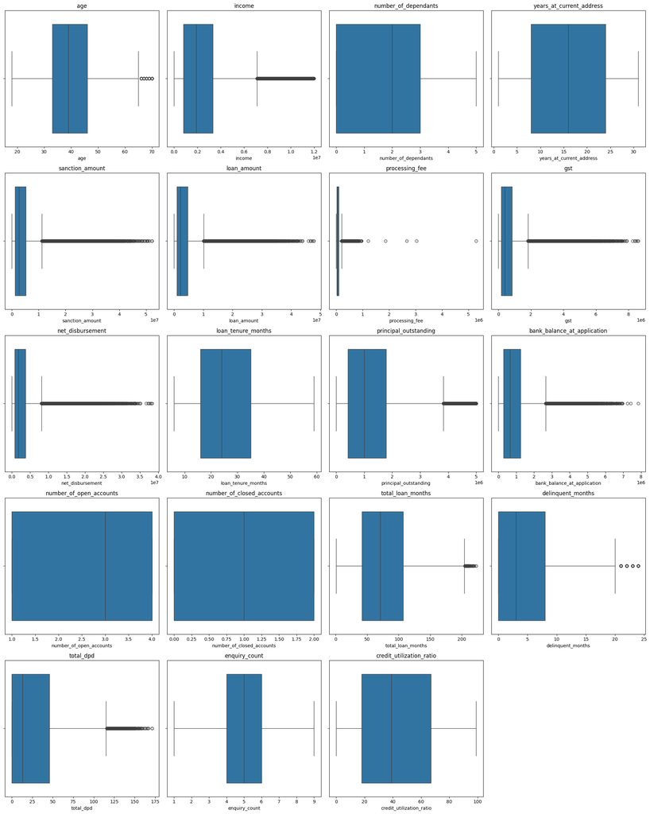

```python
num_plots = len(columns_continuous)
num_cols = 4  # Number of plots per row
num_rows = (num_plots + num_cols - 1) // num_cols  # Calculate the number of rows needed

fig, axes = plt.subplots(num_rows, num_cols, figsize=(5 * num_cols, 5 * num_rows))  # Adjust the figure size as needed
axes = axes.flatten()  # Flatten the axes array for easier indexing

for i, col in enumerate(columns_continuous):
    sns.boxplot(x=df_train[col], ax=axes[i])
    axes[i].set_title(col)  # Set the title to the name of the variable

# If there are any empty plots (if the number of plots isn't a perfect multiple of num_cols), hide the axes
for j in range(i + 1, num_rows * num_cols):
    axes[j].axis('off')

plt.tight_layout()
plt.show()
```

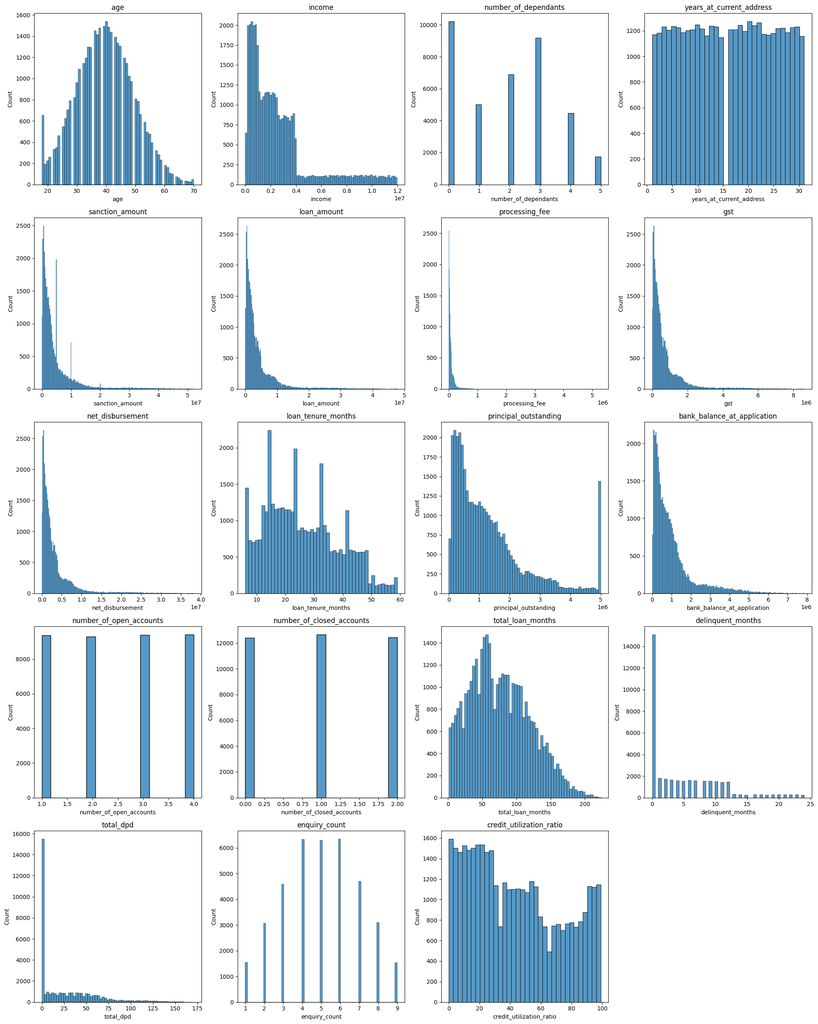

```python
num_plots = len(columns_continuous)
num_cols = 4  # Number of plots per row
num_rows = (num_plots + num_cols - 1) // num_cols  # Calculate the number of rows needed

fig, axes = plt.subplots(num_rows, num_cols, figsize=(5 * num_cols, 5 * num_rows))  # Adjust the figure size as needed
axes = axes.flatten()  # Flatten the axes array for easier indexing

for i, col in enumerate(columns_continuous):
    sns.histplot(df_train[col], ax=axes[i])
    axes[i].set_title(col)  # Set the title to the name of the variable

# If there are any empty plots (if the number of plots isn't a perfect multiple of num_cols), hide the axes
for j in range(i + 1, num_rows * num_cols):
    axes[j].axis('off')

plt.tight_layout()
plt.show()
```

### Outlier Removal: Processing Fee

```python
df_train.processing_fee.describe()
```

```
count     37500.00
mean      80290.68
std      113128.14
min           0.00
25%       19220.00
50%       44600.00
75%       92420.00
max     5293543.52
Name: processing_fee, dtype: float64
```

```python
df_train[(df_train.processing_fee/df_train.loan_amount)>0.03][["loan_amount","processing_fee"]]
```

|  | loan_amount | processing_fee |
| --- | --- | --- |
| 23981 | 2234000 | 2669791.02 |
| 28174 | 966000 | 1214492.67 |
| 47089 | 1738000 | 1858964.77 |
| 29305 | 2616000 | 3036378.01 |
| 9898 | 3626000 | 5293543.52 |

```python
df_train_1 = df_train[df_train.processing_fee/df_train.loan_amount<0.03].copy()
df_train_1.shape
```

```
(37488, 33)
```

```python
df_test.residence_type.isna().sum()
```

```
np.int64(0)
```

```python
# Apply same step on test set
df_test = df_test[df_test.processing_fee/df_test.loan_amount<0.03].copy()
df_test.shape
```

```
(12497, 33)
```

```python
# Use other business rules for data validation
# Rule 1: GST should not be more than 20%

df_train_1[(df_train_1.gst/df_train_1.loan_amount)>0.2].shape
```

```
(0, 33)
```

```python
# Rule 2: Net disbursement should not be higher than loan_amount
df_train_1[df_train_1.net_disbursement>df_train_1.loan_amount].shape
```

```
(0, 33)
```

No rows found that breaks rule 1 and rule 2

### Analyze Categorical Columns

```python
columns_categorical
```

```
['gender',
 'marital_status',
 'employment_status',
 'residence_type',
 'city',
 'state',
 'zipcode',
 'loan_purpose',
 'loan_type',
 'default']
```

```python
for col in columns_categorical:
    print(col, "-->", df_train_1[col].unique())
```

```
gender --> ['M' 'F']
marital_status --> ['Married' 'Single']
employment_status --> ['Self-Employed' 'Salaried']
residence_type --> ['Owned' 'Mortgage' 'Rented']
city --> ['Hyderabad' 'Mumbai' 'Chennai' 'Bangalore' 'Pune' 'Kolkata' 'Ahmedabad'
 'Delhi' 'Lucknow' 'Jaipur']
state --> ['Telangana' 'Maharashtra' 'Tamil Nadu' 'Karnataka' 'West Bengal'
 'Gujarat' 'Delhi' 'Uttar Pradesh' 'Rajasthan']
zipcode --> [500001 400001 600001 560001 411001 700001 380001 110001 226001 302001]
loan_purpose --> ['Home' 'Education' 'Personal' 'Auto' 'Personaal']
loan_type --> ['Secured' 'Unsecured']
default --> [0 1]
```

### Fix Errors in Loan Purpose Column

```python
df_train_1['loan_purpose'] = df_train_1['loan_purpose'].replace('Personaal', 'Personal')
df_train_1['loan_purpose'].unique()
```

```
array(['Home', 'Education', 'Personal', 'Auto'], dtype=object)
```

```python
df_test['loan_purpose'] = df_test['loan_purpose'].replace('Personaal', 'Personal')
df_test['loan_purpose'].unique()
```

```
array(['Home', 'Education', 'Auto', 'Personal'], dtype=object)
```

### Exploratory Data Analysis

```python
columns_continuous
```

```
['age',
 'income',
 'number_of_dependants',
 'years_at_current_address',
 'sanction_amount',
 'loan_amount',
 'processing_fee',
 'gst',
 'net_disbursement',
 'loan_tenure_months',
 'principal_outstanding',
 'bank_balance_at_application',
 'number_of_open_accounts',
 'number_of_closed_accounts',
 'total_loan_months',
 'delinquent_months',
 'total_dpd',
 'enquiry_count',
 'credit_utilization_ratio']
```

### Age Column

```python
df_train_1.groupby("default")['age'].describe()
```

| default | count | mean | std | min | 25% | 50% | 75% | max |
| --- | --- | --- | --- | --- | --- | --- | --- | --- |
| 0 | 34265.00 | 39.77 | 9.88 | 18.00 | 33.00 | 40.00 | 46.00 | 70.00 |
| 1 | 3223.00 | 37.12 | 9.29 | 18.00 | 31.00 | 37.00 | 44.00 | 70.00 |

**Insights**

1. Average age in the default group is little less (37.12) than the average (39.7) of the group that did not default
2. Variability (standard deviation) is mostly similar in both the groups
3. Both the groups have similar min and max ages

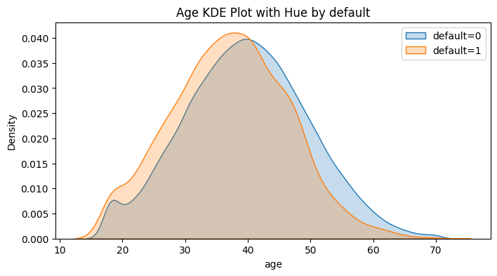

```python
plt.figure(figsize=(8, 4))
sns.kdeplot(df_train_1['age'][df_train_1['default'] == 0], fill=True, label='default=0')
sns.kdeplot(df_train_1['age'][df_train_1['default'] == 1], fill=True, label='default=1')
plt.title(f"Age KDE Plot with Hue by default")
plt.legend()
plt.show()
```

**Insights**

1. Orange (defaulted) group is slightly shifted to left indicating that younger folks are more likely to default on their loans

### KDE for all the Columns

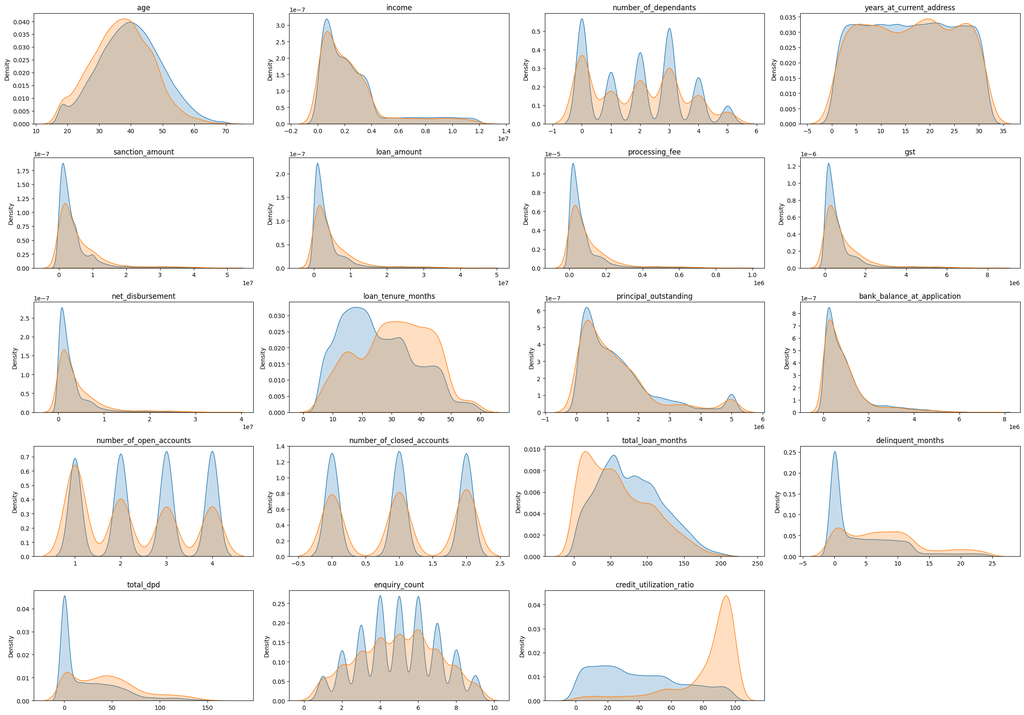

```python
plt.figure(figsize=(24, 20))  # Width, height in inches

for i, col in enumerate(columns_continuous):
    plt.subplot(6, 4, i+1)  # 1 row, 4 columns, ith subplot
    sns.kdeplot(df_train_1[col][df_train_1['default']==0], fill=True, label='default=0')
    sns.kdeplot(df_train_1[col][df_train_1['default']==1], fill=True, label='default=1')
    plt.title(col)
    plt.xlabel('')

plt.tight_layout()
plt.show()
```

**Insights**

1. In columns: loan_tenure_months, delinquent_months, total_dpd, credit_utilization, higher values indicate high likelyhood of becoming a default. Hence these 4 looks like strong predictors
2. In remaining columns the distributions do not give any obvious insights
3. Why loan_amount and income did not give any signs of being strong predictors? May be when we combine these two and get loan to income ratio (LTI), that may have influence on the target variable. We will explore more later

### Feature Engineering, Feature Selection

#### Generate Loan to Income (LTI) Ratio

```python
df_train_1[["loan_amount", "income"]].head(3)
```

|  | loan_amount | income |
| --- | --- | --- |
| 12746 | 23442000 | 11327000 |
| 32495 | 1149000 | 715000 |
| 43675 | 11296000 | 3195000 |

```python
df_train_1['loan_to_income'] = round(df_train_1['loan_amount'] / df_train_1['income'],2)
df_train_1['loan_to_income'].describe()
```

```
count   37488.00
mean        1.56
std         0.97
min         0.30
25%         0.77
50%         1.16
75%         2.46
max         4.57
Name: loan_to_income, dtype: float64
```

```python
df_test['loan_to_income'] = round(df_test['loan_amount'] / df_test['income'],2)
```

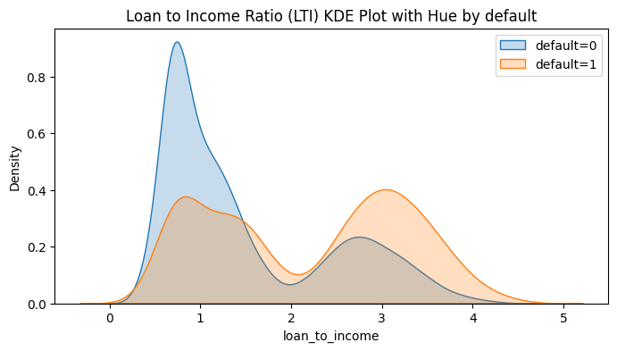

```python
plt.figure(figsize=(8, 4))
sns.kdeplot(df_train_1['loan_to_income'][df_train_1['default'] == 0], fill=True, label='default=0')
sns.kdeplot(df_train_1['loan_to_income'][df_train_1['default'] == 1], fill=True, label='default=1')
plt.title(f"Loan to Income Ratio (LTI) KDE Plot with Hue by default")
plt.legend()
plt.show()
```

**Insights**

1. Blue graph has majority of its values on lower side of LTI
2. Orange graph has many values when LTI is higher indicating that higher LTI means high risk loan

#### Generate Delinquency Ratio

```python
df_train_1['delinquency_ratio'] = (df_train_1['delinquent_months']*100 / df_train_1['total_loan_months']).round(1)
df_test['delinquency_ratio'] = (df_test['delinquent_months']*100 / df_test['total_loan_months']).round(1)
```

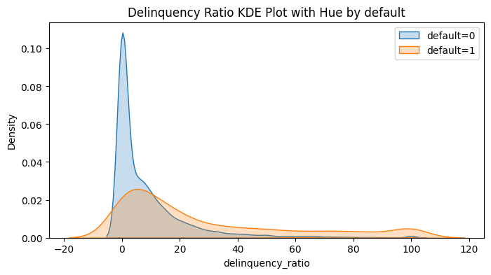

```python
plt.figure(figsize=(8, 4))
sns.kdeplot(df_train_1['delinquency_ratio'][df_train_1['default'] == 0], fill=True, label='default=0')
sns.kdeplot(df_train_1['delinquency_ratio'][df_train_1['default'] == 1], fill=True, label='default=1')
plt.title(f"Delinquency Ratio KDE Plot with Hue by default")
plt.legend()
plt.show()
```

**Insights**

#### Generate Avg DPD Per Delinquency

```python
df_train_1['avg_dpd_per_delinquency'] = np.where(
    df_train_1['delinquent_months'] != 0,
    (df_train_1['total_dpd'] / df_train_1['delinquent_months']).round(1),
    0
)

df_test['avg_dpd_per_delinquency'] = np.where(
    df_test['delinquent_months'] != 0,
    (df_test['total_dpd'] / df_test['delinquent_months']).round(1),
    0
)
```

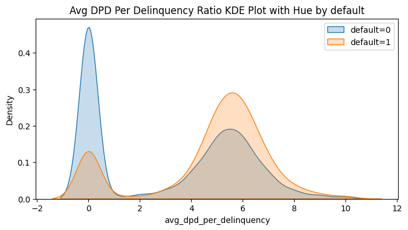

```python
plt.figure(figsize=(8, 4))
sns.kdeplot(df_train_1['avg_dpd_per_delinquency'][df_train_1['default'] == 0], fill=True, label='default=0')
sns.kdeplot(df_train_1['avg_dpd_per_delinquency'][df_train_1['default'] == 1], fill=True, label='default=1')
plt.title(f"Avg DPD Per Delinquency Ratio KDE Plot with Hue by default")
plt.legend()
plt.show()
```

**Insights**

1. Graph clearly shows more occurances of default cases when avg_dpd_per_delinquency is high. This means this column is a strong predictor

### Remove columns that are just unique ids and don't have influence on target

```python
df_train_1.columns
```

```
Index(['cust_id', 'age', 'gender', 'marital_status', 'employment_status',
       'income', 'number_of_dependants', 'residence_type',
       'years_at_current_address', 'city', 'state', 'zipcode', 'loan_id',
       'loan_purpose', 'loan_type', 'sanction_amount', 'loan_amount',
       'processing_fee', 'gst', 'net_disbursement', 'loan_tenure_months',
       'principal_outstanding', 'bank_balance_at_application',
       'disbursal_date', 'installment_start_dt', 'number_of_open_accounts',
       'number_of_closed_accounts', 'total_loan_months', 'delinquent_months',
       'total_dpd', 'enquiry_count', 'credit_utilization_ratio', 'default',
       'loan_to_income', 'delinquency_ratio', 'avg_dpd_per_delinquency'],
      dtype='object')
```

```python
df_train_2 = df_train_1.drop(['cust_id', 'loan_id'],axis="columns")
df_test = df_test.drop(['cust_id', 'loan_id'],axis="columns")
```

### Remove columns that business contact person asked us to remove

```python
df_train_3 = df_train_2.drop(['disbursal_date', 'installment_start_dt', 'loan_amount', 'income',
                              'total_loan_months', 'delinquent_months', 'total_dpd'], axis="columns")
df_test = df_test.drop(['disbursal_date', 'installment_start_dt', 'loan_amount', 'income',
                              'total_loan_months', 'delinquent_months', 'total_dpd'], axis="columns")
df_train_3.columns
```

```
Index(['age', 'gender', 'marital_status', 'employment_status',
       'number_of_dependants', 'residence_type', 'years_at_current_address',
       'city', 'state', 'zipcode', 'loan_purpose', 'loan_type',
       'sanction_amount', 'processing_fee', 'gst', 'net_disbursement',
       'loan_tenure_months', 'principal_outstanding',
       'bank_balance_at_application', 'number_of_open_accounts',
       'number_of_closed_accounts', 'enquiry_count',
       'credit_utilization_ratio', 'default', 'loan_to_income',
       'delinquency_ratio', 'avg_dpd_per_delinquency'],
      dtype='object')
```

```python
df_train_3.select_dtypes(['int64', 'float64']).columns
```

```
Index(['age', 'number_of_dependants', 'years_at_current_address', 'zipcode',
       'sanction_amount', 'processing_fee', 'gst', 'net_disbursement',
       'loan_tenure_months', 'principal_outstanding',
       'bank_balance_at_application', 'number_of_open_accounts',
       'number_of_closed_accounts', 'enquiry_count',
       'credit_utilization_ratio', 'loan_to_income', 'delinquency_ratio',
       'avg_dpd_per_delinquency'],
      dtype='object')
```

### VIF to measure multicolinearity

```python
X_train = df_train_3.drop('default', axis='columns')
y_train = df_train_3['default']

from sklearn.preprocessing import MinMaxScaler

cols_to_scale = X_train.select_dtypes(['int64', 'float64']).columns

scaler = MinMaxScaler()

X_train[cols_to_scale] = scaler.fit_transform(X_train[cols_to_scale])
X_train.describe()
```

|  | age | number_of_dependants | years_at_current_address | zipcode | sanction_amount | processing_fee | gst | net_disbursement | loan_tenure_months | principal_outstanding | bank_balance_at_application | number_of_open_accounts | number_of_closed_accounts | enquiry_count | credit_utilization_ratio | loan_to_income | delinquency_ratio | avg_dpd_per_delinquency |
| --- | --- | --- | --- | --- | --- | --- | --- | --- | --- | --- | --- | --- | --- | --- | --- | --- | --- | --- |
| count | 37488.00 | 37488.00 | 37488.00 | 37488.00 | 37488.00 | 37488.00 | 37488.00 | 37488.00 | 37488.00 | 37488.00 | 37488.00 | 37488.00 | 37488.00 | 37488.00 | 37488.00 | 37488.00 | 37488.00 | 37488.00 |
| mean | 0.41 | 0.39 | 0.50 | 0.52 | 0.09 | 0.08 | 0.08 | 0.08 | 0.38 | 0.26 | 0.12 | 0.50 | 0.50 | 0.50 | 0.44 | 0.29 | 0.10 | 0.33 |
| std | 0.19 | 0.31 | 0.30 | 0.29 | 0.12 | 0.11 | 0.11 | 0.11 | 0.23 | 0.24 | 0.13 | 0.37 | 0.41 | 0.25 | 0.30 | 0.23 | 0.17 | 0.29 |
| min | 0.00 | 0.00 | 0.00 | 0.00 | 0.00 | 0.00 | 0.00 | 0.00 | 0.00 | 0.00 | 0.00 | 0.00 | 0.00 | 0.00 | 0.00 | 0.00 | 0.00 | 0.00 |
| 25% | 0.29 | 0.00 | 0.23 | 0.33 | 0.02 | 0.02 | 0.02 | 0.02 | 0.19 | 0.08 | 0.03 | 0.00 | 0.00 | 0.38 | 0.18 | 0.11 | 0.00 | 0.00 |
| 50% | 0.40 | 0.40 | 0.50 | 0.49 | 0.05 | 0.05 | 0.05 | 0.05 | 0.34 | 0.19 | 0.08 | 0.67 | 0.50 | 0.50 | 0.39 | 0.20 | 0.04 | 0.43 |
| 75% | 0.54 | 0.60 | 0.77 | 0.76 | 0.10 | 0.10 | 0.10 | 0.10 | 0.55 | 0.35 | 0.16 | 1.00 | 1.00 | 0.62 | 0.68 | 0.51 | 0.13 | 0.57 |
| max | 1.00 | 1.00 | 1.00 | 1.00 | 1.00 | 1.00 | 1.00 | 1.00 | 1.00 | 1.00 | 1.00 | 1.00 | 1.00 | 1.00 | 1.00 | 1.00 | 1.00 | 1.00 |

#### Same transformation on test set

```python
X_test = df_test.drop('default', axis='columns')
y_test = df_test['default']

X_test[cols_to_scale] = scaler.transform(X_test[cols_to_scale])
X_test.describe()
```

|  | age | number_of_dependants | years_at_current_address | zipcode | sanction_amount | processing_fee | gst | net_disbursement | loan_tenure_months | principal_outstanding | bank_balance_at_application | number_of_open_accounts | number_of_closed_accounts | enquiry_count | credit_utilization_ratio | loan_to_income | delinquency_ratio | avg_dpd_per_delinquency |
| --- | --- | --- | --- | --- | --- | --- | --- | --- | --- | --- | --- | --- | --- | --- | --- | --- | --- | --- |
| count | 12497.00 | 12497.00 | 12497.00 | 12497.00 | 12497.00 | 12497.00 | 12497.00 | 12497.00 | 12497.00 | 12497.00 | 12497.00 | 12497.00 | 12497.00 | 12497.00 | 12497.00 | 12497.00 | 12497.00 | 12497.00 |
| mean | 0.42 | 0.38 | 0.50 | 0.53 | 0.09 | 0.08 | 0.08 | 0.08 | 0.38 | 0.26 | 0.12 | 0.50 | 0.50 | 0.50 | 0.44 | 0.29 | 0.11 | 0.33 |
| std | 0.19 | 0.31 | 0.30 | 0.29 | 0.12 | 0.11 | 0.11 | 0.11 | 0.23 | 0.25 | 0.13 | 0.37 | 0.41 | 0.25 | 0.30 | 0.23 | 0.17 | 0.29 |
| min | 0.00 | 0.00 | 0.00 | 0.00 | -0.00 | -0.00 | -0.00 | -0.00 | 0.00 | 0.00 | 0.00 | 0.00 | 0.00 | 0.00 | 0.00 | 0.00 | 0.00 | 0.00 |
| 25% | 0.29 | 0.00 | 0.23 | 0.33 | 0.02 | 0.02 | 0.02 | 0.02 | 0.19 | 0.08 | 0.03 | 0.00 | 0.00 | 0.38 | 0.18 | 0.11 | 0.00 | 0.00 |
| 50% | 0.42 | 0.40 | 0.50 | 0.51 | 0.05 | 0.05 | 0.05 | 0.05 | 0.34 | 0.20 | 0.08 | 0.33 | 0.50 | 0.50 | 0.39 | 0.20 | 0.04 | 0.44 |
| 75% | 0.54 | 0.60 | 0.77 | 0.76 | 0.10 | 0.09 | 0.09 | 0.09 | 0.55 | 0.36 | 0.16 | 0.67 | 1.00 | 0.62 | 0.68 | 0.50 | 0.13 | 0.58 |
| max | 1.00 | 1.00 | 1.00 | 1.00 | 0.98 | 0.96 | 0.96 | 0.96 | 1.00 | 1.00 | 0.94 | 1.00 | 1.00 | 1.00 | 1.00 | 1.00 | 1.00 | 1.00 |

```python
from statsmodels.stats.outliers_influence import variance_inflation_factor

def calculate_vif(data):
    vif_df = pd.DataFrame()
    vif_df['Column'] = data.columns
    vif_df['VIF'] = [variance_inflation_factor(data.values,i) for i in range(data.shape[1])]
    return vif_df
```

```python
X_train.head(2)
```

|  | age | gender | marital_status | employment_status | number_of_dependants | residence_type | years_at_current_address | city | state | zipcode | ... | loan_tenure_months | principal_outstanding | bank_balance_at_application | number_of_open_accounts | number_of_closed_accounts | enquiry_count | credit_utilization_ratio | loan_to_income | delinquency_ratio | avg_dpd_per_delinquency |
| --- | --- | --- | --- | --- | --- | --- | --- | --- | --- | --- | --- | --- | --- | --- | --- | --- | --- | --- | --- | --- | --- |
| 12746 | 0.79 | M | Married | Self-Employed | 0.60 | Owned | 0.97 | Hyderabad | Telangana | 0.66 | ... | 0.42 | 1.00 | 0.61 | 1.00 | 1.00 | 0.38 | 0.36 | 0.41 | 0.13 | 0.59 |
| 32495 | 0.50 | F | Single | Salaried | 0.00 | Owned | 0.87 | Mumbai | Maharashtra | 0.49 | ... | 0.83 | 0.09 | 0.03 | 0.67 | 0.50 | 0.50 | 0.05 | 0.31 | 0.06 | 0.62 |

2 rows × 26 columns

```python
calculate_vif(X_train[cols_to_scale])
```

|  | Column | VIF |
| --- | --- | --- |
| 0 | age | 5.70 |
| 1 | number_of_dependants | 2.73 |
| 2 | years_at_current_address | 3.42 |
| 3 | zipcode | 3.80 |
| 4 | sanction_amount | 101.09 |
| 5 | processing_fee | inf |
| 6 | gst | inf |
| 7 | net_disbursement | inf |
| 8 | loan_tenure_months | 6.18 |
| 9 | principal_outstanding | 16.33 |
| 10 | bank_balance_at_application | 9.34 |
| 11 | number_of_open_accounts | 4.39 |
| 12 | number_of_closed_accounts | 2.38 |
| 13 | enquiry_count | 6.41 |
| 14 | credit_utilization_ratio | 2.93 |
| 15 | loan_to_income | 6.96 |
| 16 | delinquency_ratio | 1.93 |
| 17 | avg_dpd_per_delinquency | 2.91 |

```python
features_to_drop_vif = ['sanction_amount', 'processing_fee', 'gst', 'net_disbursement','principal_outstanding']


X_train_1 = X_train.drop(features_to_drop_vif, axis='columns')
numeric_columns = X_train_1.select_dtypes(['int64', 'float64']).columns
numeric_columns
```

```
Index(['age', 'number_of_dependants', 'years_at_current_address', 'zipcode',
       'loan_tenure_months', 'bank_balance_at_application',
       'number_of_open_accounts', 'number_of_closed_accounts', 'enquiry_count',
       'credit_utilization_ratio', 'loan_to_income', 'delinquency_ratio',
       'avg_dpd_per_delinquency'],
      dtype='object')
```

```python
calculate_vif(X_train_1[numeric_columns])
```

|  | Column | VIF |
| --- | --- | --- |
| 0 | age | 5.43 |
| 1 | number_of_dependants | 2.73 |
| 2 | years_at_current_address | 3.40 |
| 3 | zipcode | 3.78 |
| 4 | loan_tenure_months | 6.02 |
| 5 | bank_balance_at_application | 1.80 |
| 6 | number_of_open_accounts | 4.35 |
| 7 | number_of_closed_accounts | 2.37 |
| 8 | enquiry_count | 6.38 |
| 9 | credit_utilization_ratio | 2.92 |
| 10 | loan_to_income | 4.56 |
| 11 | delinquency_ratio | 1.93 |
| 12 | avg_dpd_per_delinquency | 2.91 |

```python
selected_numeric_features_vif = vif_df.Column.values
selected_numeric_features_vif
```

[output not shown]

```python
numeric_columns
```

```
Index(['age', 'number_of_dependants', 'years_at_current_address', 'zipcode',
       'loan_tenure_months', 'bank_balance_at_application',
       'number_of_open_accounts', 'number_of_closed_accounts', 'enquiry_count',
       'credit_utilization_ratio', 'loan_to_income', 'delinquency_ratio',
       'avg_dpd_per_delinquency'],
      dtype='object')
```

```python
numeric_columns
```

```
Index(['age', 'number_of_dependants', 'years_at_current_address', 'zipcode',
       'loan_tenure_months', 'bank_balance_at_application',
       'number_of_open_accounts', 'number_of_closed_accounts', 'enquiry_count',
       'credit_utilization_ratio', 'loan_to_income', 'delinquency_ratio',
       'avg_dpd_per_delinquency'],
      dtype='object')
```

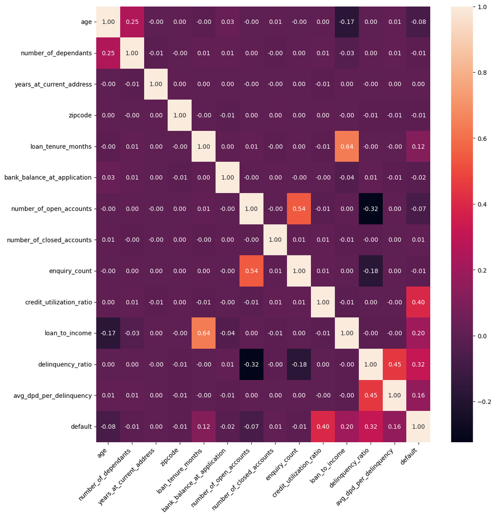

```python
plt.figure(figsize=(12,12))
cm = df_train_3[numeric_columns.append(pd.Index(['default']))].corr()
sns.heatmap(cm, annot=True, fmt='0.2f')
plt.xticks(rotation=45, ha='right')
plt.yticks(rotation=0)
plt.tight_layout()
plt.show()
```

### Feature Selection: Categorical Features

```python
X_train_1.head()
```

|  | age | gender | marital_status | employment_status | number_of_dependants | residence_type | years_at_current_address | city | state | zipcode | ... | loan_type | loan_tenure_months | bank_balance_at_application | number_of_open_accounts | number_of_closed_accounts | enquiry_count | credit_utilization_ratio | loan_to_income | delinquency_ratio | avg_dpd_per_delinquency |
| --- | --- | --- | --- | --- | --- | --- | --- | --- | --- | --- | --- | --- | --- | --- | --- | --- | --- | --- | --- | --- | --- |
| 12746 | 0.79 | M | Married | Self-Employed | 0.60 | Owned | 0.97 | Hyderabad | Telangana | 0.66 | ... | Secured | 0.42 | 0.61 | 1.00 | 1.00 | 0.38 | 0.36 | 0.41 | 0.13 | 0.59 |
| 32495 | 0.50 | F | Single | Salaried | 0.00 | Owned | 0.87 | Mumbai | Maharashtra | 0.49 | ... | Secured | 0.83 | 0.03 | 0.67 | 0.50 | 0.50 | 0.05 | 0.31 | 0.06 | 0.62 |
| 43675 | 0.38 | M | Single | Salaried | 0.00 | Mortgage | 0.83 | Chennai | Tamil Nadu | 0.83 | ... | Secured | 0.49 | 0.17 | 0.00 | 0.50 | 0.38 | 0.00 | 0.76 | 0.22 | 0.56 |
| 9040 | 0.46 | M | Married | Salaried | 0.40 | Mortgage | 0.97 | Bangalore | Karnataka | 0.76 | ... | Secured | 0.64 | 0.08 | 0.67 | 0.00 | 0.88 | 0.88 | 0.19 | 0.00 | 0.00 |
| 13077 | 0.77 | M | Married | Self-Employed | 0.80 | Owned | 0.93 | Pune | Maharashtra | 0.51 | ... | Unsecured | 0.17 | 0.07 | 0.00 | 1.00 | 0.00 | 0.72 | 0.05 | 0.00 | 0.00 |

5 rows × 21 columns

### Calculate WOE and IV

```python
def calculate_woe_iv(df, feature, target):
    grouped = df.groupby(feature)[target].agg(['count','sum'])
    grouped = grouped.rename(columns={'count': 'total', 'sum': 'good'})
    grouped['bad']=grouped['total']-grouped['good']

    total_good = grouped['good'].sum()
    total_bad = grouped['bad'].sum()

    grouped['good_pct'] = grouped['good'] / total_good
    grouped['bad_pct'] = grouped['bad'] / total_bad
    grouped['woe'] = np.log(grouped['good_pct']/ grouped['bad_pct'])
    grouped['iv'] = (grouped['good_pct'] -grouped['bad_pct'])*grouped['woe']

    grouped['woe'] = grouped['woe'].replace([np.inf, -np.inf], 0)
    grouped['iv'] = grouped['iv'].replace([np.inf, -np.inf], 0)

    total_iv = grouped['iv'].sum()

    return grouped, total_iv

grouped, total_iv = calculate_woe_iv(pd.concat([X_train_1, y_train],axis=1), 'loan_purpose', 'default')
grouped
```

| loan_purpose | total | good | bad | good_pct | bad_pct | woe | iv |
| --- | --- | --- | --- | --- | --- | --- | --- |
| Auto | 7447 | 327 | 7120 | 0.10 | 0.21 | -0.72 | 0.08 |
| Education | 5620 | 559 | 5061 | 0.17 | 0.15 | 0.16 | 0.00 |
| Home | 11304 | 1734 | 9570 | 0.54 | 0.28 | 0.66 | 0.17 |
| Personal | 13117 | 603 | 12514 | 0.19 | 0.37 | -0.67 | 0.12 |

```python
X_train_1.info()
```

```
<class 'pandas.core.frame.DataFrame'>
Index: 37488 entries, 12746 to 37784
Data columns (total 21 columns):
 #   Column                       Non-Null Count  Dtype
---  ------                       --------------  -----
 0   age                          37488 non-null  float64
 1   gender                       37488 non-null  object
 2   marital_status               37488 non-null  object
 3   employment_status            37488 non-null  object
 4   number_of_dependants         37488 non-null  float64
 5   residence_type               37488 non-null  object
 6   years_at_current_address     37488 non-null  float64
 7   city                         37488 non-null  object
 8   state                        37488 non-null  object
 9   zipcode                      37488 non-null  float64
 10  loan_purpose                 37488 non-null  object
 11  loan_type                    37488 non-null  object
 12  loan_tenure_months           37488 non-null  float64
 13  bank_balance_at_application  37488 non-null  float64
 14  number_of_open_accounts      37488 non-null  float64
 15  number_of_closed_accounts    37488 non-null  float64
 16  enquiry_count                37488 non-null  float64
 17  credit_utilization_ratio     37488 non-null  float64
 18  loan_to_income               37488 non-null  float64
 19  delinquency_ratio            37488 non-null  float64
 20  avg_dpd_per_delinquency      37488 non-null  float64
dtypes: float64(13), object(8)
memory usage: 6.3+ MB
```

```python
iv_values = {}

for feature in X_train_1.columns:
    if X_train_1[feature].dtype == 'object':
        _, iv = calculate_woe_iv(pd.concat([X_train_1, y_train],axis=1), feature, 'default' )
    else:
        X_binned = pd.cut(X_train_1[feature], bins=10, labels=False)
        _, iv = calculate_woe_iv(pd.concat([X_binned, y_train],axis=1), feature, 'default' )
    iv_values[feature] = iv

iv_values
```

```
{'age': 0.0890689462679479,
 'gender': 0.00047449502170914947,
 'marital_status': 0.001129766845390142,
 'employment_status': 0.003953046301722585,
 'number_of_dependants': 0.0019380899135053508,
 'residence_type': 0.246745268718145,
 'years_at_current_address': 0.0020800513608156363,
 'city': 0.0019059578709781529,
 'state': 0.0019005589806779287,
 'zipcode': 0.0016677413243392572,
 'loan_purpose': 0.3691197842282755,
 'loan_type': 0.16319324904149224,
 'loan_tenure_months': 0.21893515090196278,
 'bank_balance_at_application': 0.0063187993277516365,
 'number_of_open_accounts': 0.08463134083005877,
 'number_of_closed_accounts': 0.0011964272592421567,
 'enquiry_count': 0.007864214085342608,
 'credit_utilization_ratio': 2.352965568168245,
 'loan_to_income': 0.476415456948364,
 'delinquency_ratio': 0.716576108689321,
 'avg_dpd_per_delinquency': 0.40151905412190175}
```

```python
pd.set_option('display.float_format', lambda x: '{:.3f}'.format(x))

iv_df = pd.DataFrame(list(iv_values.items()), columns=['Feature', 'IV'])
iv_df = iv_df.sort_values(by='IV', ascending=False)
iv_df
```

|  | Feature | IV |
| --- | --- | --- |
| 17 | credit_utilization_ratio | 2.353 |
| 19 | delinquency_ratio | 0.717 |
| 18 | loan_to_income | 0.476 |
| 20 | avg_dpd_per_delinquency | 0.402 |
| 10 | loan_purpose | 0.369 |
| 5 | residence_type | 0.247 |
| 12 | loan_tenure_months | 0.219 |
| 11 | loan_type | 0.163 |
| 0 | age | 0.089 |
| 14 | number_of_open_accounts | 0.085 |
| 16 | enquiry_count | 0.008 |
| 13 | bank_balance_at_application | 0.006 |
| 3 | employment_status | 0.004 |
| 6 | years_at_current_address | 0.002 |
| 4 | number_of_dependants | 0.002 |
| 7 | city | 0.002 |
| 8 | state | 0.002 |
| 9 | zipcode | 0.002 |
| 15 | number_of_closed_accounts | 0.001 |
| 2 | marital_status | 0.001 |
| 1 | gender | 0.000 |

```python
# select features that has IV > 0.02
selected_features_iv = [feature for feature, iv in iv_values.items() if iv > 0.02]
selected_features_iv
```

```
['age',
 'residence_type',
 'loan_purpose',
 'loan_type',
 'loan_tenure_months',
 'number_of_open_accounts',
 'credit_utilization_ratio',
 'loan_to_income',
 'delinquency_ratio',
 'avg_dpd_per_delinquency']
```

### Feature Encoding

```python
X_train_reduced = X_train_1[selected_features_iv]
X_test_reduced = X_test[selected_features_iv]
```

```python
X_train_encoded = pd.get_dummies(X_train_reduced, drop_first=True)
X_train_encoded.head(3)
```

|  | age | loan_tenure_months | number_of_open_accounts | credit_utilization_ratio | loan_to_income | delinquency_ratio | avg_dpd_per_delinquency | residence_type_Owned | residence_type_Rented | loan_purpose_Education | loan_purpose_Home | loan_purpose_Personal | loan_type_Unsecured |
| --- | --- | --- | --- | --- | --- | --- | --- | --- | --- | --- | --- | --- | --- |
| 12746 | 0.788 | 0.415 | 1.000 | 0.364 | 0.415 | 0.132 | 0.590 | True | False | False | True | False | False |
| 32495 | 0.500 | 0.830 | 0.667 | 0.051 | 0.307 | 0.062 | 0.620 | True | False | True | False | False | False |
| 43675 | 0.385 | 0.491 | 0.000 | 0.000 | 0.759 | 0.222 | 0.560 | False | False | False | True | False | False |

```python
X_test_encoded = pd.get_dummies(X_test_reduced, drop_first=True)
X_test_encoded.head(3)
```

|  | age | loan_tenure_months | number_of_open_accounts | credit_utilization_ratio | loan_to_income | delinquency_ratio | avg_dpd_per_delinquency | residence_type_Owned | residence_type_Rented | loan_purpose_Education | loan_purpose_Home | loan_purpose_Personal | loan_type_Unsecured |
| --- | --- | --- | --- | --- | --- | --- | --- | --- | --- | --- | --- | --- | --- |
| 19205 | 0.346 | 0.755 | 0.333 | 0.990 | 0.550 | 0.000 | 0.000 | True | False | False | True | False | False |
| 15514 | 0.481 | 0.226 | 1.000 | 0.323 | 0.220 | 0.000 | 0.000 | True | False | True | False | False | False |
| 30367 | 0.231 | 0.547 | 0.667 | 0.828 | 0.180 | 0.000 | 0.000 | True | False | False | False | False | False |

### Attempt 1

1. Logistic Regression, RandomForest & XGB
2. No handling of class imbalance

```python
from sklearn.linear_model import LogisticRegression
from sklearn.metrics import classification_report

model = LogisticRegression()
model.fit(X_train_encoded, y_train)

y_pred = model.predict(X_test_encoded)
report = classification_report(y_test, y_pred)
print(report)
```

```
              precision    recall  f1-score   support

           0       0.97      0.99      0.98     11423
           1       0.84      0.72      0.78      1074

    accuracy                           0.96     12497
   macro avg       0.91      0.85      0.88     12497
weighted avg       0.96      0.96      0.96     12497
```

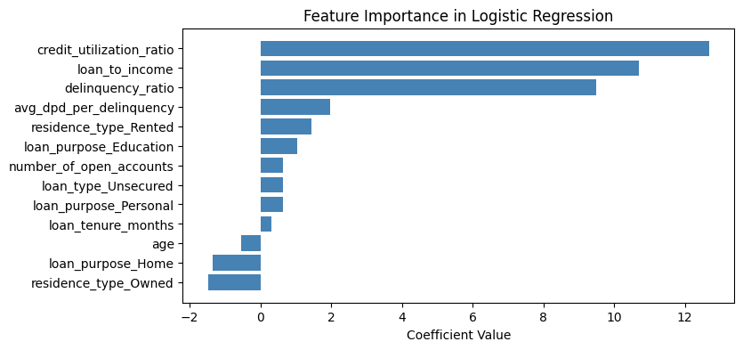

```python
feature_importance = model.coef_[0]

# Create a DataFrame for easier handling
coef_df = pd.DataFrame(feature_importance, index=X_train_encoded.columns, columns=['Coefficients'])

# Sort the coefficients for better visualization
coef_df = coef_df.sort_values(by='Coefficients', ascending=True)

# Plotting
plt.figure(figsize=(8, 4))
plt.barh(coef_df.index, coef_df['Coefficients'], color='steelblue')
plt.xlabel('Coefficient Value')
plt.title('Feature Importance in Logistic Regression')
plt.show()
```

```python
from sklearn.ensemble import RandomForestClassifier

model = RandomForestClassifier()
model.fit(X_train_encoded, y_train)

y_pred = model.predict(X_test_encoded)
report = classification_report(y_test, y_pred)
print(report)
```

```
              precision    recall  f1-score   support

           0       0.97      0.99      0.98     11423
           1       0.85      0.71      0.78      1074

    accuracy                           0.96     12497
   macro avg       0.91      0.85      0.88     12497
weighted avg       0.96      0.96      0.96     12497
```

```python
from xgboost import XGBClassifier

model = XGBClassifier()
model.fit(X_train_encoded, y_train)

y_pred = model.predict(X_test_encoded)
report = classification_report(y_test, y_pred)
print(report)
```

```
              precision    recall  f1-score   support

           0       0.98      0.98      0.98     11423
           1       0.82      0.76      0.79      1074

    accuracy                           0.96     12497
   macro avg       0.90      0.87      0.88     12497
weighted avg       0.96      0.96      0.96     12497
```

Since there is not much difference between XGB and Logistic, we will choose LogisticRegression as a candidate for our RandomizedSearchCV candidate it has a better interpretation.

#### RandomizedSearch CV for Attempt 1: Logistic Regression

```python
from sklearn.model_selection import RandomizedSearchCV

param_dist = {
    'C': np.logspace(-4, 4, 20),  # Logarithmically spaced values from 10^-4 to 10^4
    'solver': ['lbfgs', 'saga', 'liblinear', 'newton-cg']   # Algorithm to use in the optimization problem
}

# Create the Logistic Regression model
log_reg = LogisticRegression(max_iter=10000)  # Increased max_iter for convergence

# Set up RandomizedSearchCV
random_search = RandomizedSearchCV(
    estimator=log_reg,
    param_distributions=param_dist,
    n_iter=50,  # Number of parameter settings that are sampled
    scoring='f1',
    cv=3,  # 5-fold cross-validation
    verbose=2,
    random_state=42,  # Set a random state for reproducibility
    n_jobs=-1  # Use all available cores
)

# Fit the RandomizedSearchCV to the training data
random_search.fit(X_train_encoded, y_train)

# Print the best parameters and best score
print(f"Best Parameters: {random_search.best_params_}")
print(f"Best Score: {random_search.best_score_}")

best_model = random_search.best_estimator_
y_pred = best_model.predict(X_test_encoded)
print("Classification Report:")
print(classification_report(y_test, y_pred))
```

```
Fitting 3 folds for each of 50 candidates, totalling 150 fits
Best Parameters: {'solver': 'liblinear', 'C': 1438.44988828766}
Best Score: 0.7578820896729831
Classification Report:
              precision    recall  f1-score   support

           0       0.98      0.99      0.98     11423
           1       0.83      0.74      0.78      1074

    accuracy                           0.96     12497
   macro avg       0.90      0.86      0.88     12497
weighted avg       0.96      0.96      0.96     12497
```

#### RandomizedSearch CV for Attempt 1: XGBoost

```python
from scipy.stats import uniform, randint
from sklearn.model_selection import RandomizedSearchCV

# Define parameter distribution for RandomizedSearchCV
param_dist = {
    'n_estimators': [100, 150, 200, 250, 300],
    'max_depth': [3, 4, 5, 6, 7, 8, 9, 10],
    'learning_rate': [0.01, 0.03, 0.05, 0.1, 0.15, 0.2, 0.25, 0.3],
    'subsample': [0.6, 0.7, 0.8, 0.9, 1.0],
    'colsample_bytree': [0.6, 0.7, 0.8, 0.9, 1.0],
    'scale_pos_weight': [1, 2, 3, 5, 7, 10],
    'reg_alpha': [0.01, 0.1, 0.5, 1.0, 5.0, 10.0],  # L1 regularization term
    'reg_lambda': [0.01, 0.1, 0.5, 1.0, 5.0, 10.0]  # L2 regularization term
}

xgb = XGBClassifier()

random_search = RandomizedSearchCV(estimator=xgb, param_distributions=param_dist, n_iter=100,
                                   scoring='f1', cv=3, verbose=1, n_jobs=-1, random_state=42)

random_search.fit(X_train_encoded, y_train)

# Print the best parameters and best score
print(f"Best Parameters: {random_search.best_params_}")
print(f"Best Score: {random_search.best_score_}")

best_model = random_search.best_estimator_
y_pred = best_model.predict(X_test_encoded)
print("Classification Report:")
print(classification_report(y_test, y_pred))
```

```
Fitting 3 folds for each of 100 candidates, totalling 300 fits
Best Parameters: {'subsample': 0.9, 'scale_pos_weight': 2, 'reg_lambda': 10.0, 'reg_alpha': 10.0, 'n_estimators': 300, 'max_depth': 10, 'learning_rate': 0.2, 'colsample_bytree': 0.6}
Best Score: 0.7871111337608832
Classification Report:
              precision    recall  f1-score   support

           0       0.98      0.98      0.98     11423
           1       0.78      0.82      0.80      1074

    accuracy                           0.96     12497
   macro avg       0.88      0.90      0.89     12497
weighted avg       0.97      0.96      0.96     12497
```

### Attempt 2

1. Logistic Regression & XGB
2. Handle Class Imbalance Using Under Sampling

```python
from imblearn.under_sampling import RandomUnderSampler

rus = RandomUnderSampler(random_state=42)
X_train_res, y_train_res = rus.fit_resample(X_train_encoded, y_train)
y_train_res.value_counts()
```

```
default
0    3223
1    3223
Name: count, dtype: int64
```

```python
model = LogisticRegression()
model.fit(X_train_res, y_train_res)

y_pred = model.predict(X_test_encoded)
report = classification_report(y_test, y_pred)
print(report)
```

```
              precision    recall  f1-score   support

           0       1.00      0.91      0.95     11423
           1       0.51      0.96      0.67      1074

    accuracy                           0.92     12497
   macro avg       0.75      0.93      0.81     12497
weighted avg       0.95      0.92      0.93     12497
```

```python
model = XGBClassifier(**random_search.best_params_)
model.fit(X_train_res, y_train_res)

y_pred = model.predict(X_test_encoded)
report = classification_report(y_test, y_pred)
print(report)
```

```
              precision    recall  f1-score   support

           0       1.00      0.92      0.96     11423
           1       0.52      0.99      0.68      1074

    accuracy                           0.92     12497
   macro avg       0.76      0.95      0.82     12497
weighted avg       0.96      0.92      0.93     12497
```

### Attempt 3

1. Logistic Regression
2. Handle Class Imbalance Using SMOTE Tomek
3. Parameter tunning using optuna

```python
from imblearn.combine import SMOTETomek

smt = SMOTETomek(random_state=42)
X_train_smt, y_train_smt = smt.fit_resample(X_train_encoded, y_train)
y_train_smt.value_counts()
```

```
default
0    34195
1    34195
Name: count, dtype: int64
```

```python
model = LogisticRegression()
model.fit(X_train_smt, y_train_smt)

y_pred = model.predict(X_test_encoded)
report = classification_report(y_test, y_pred)
print(report)
```

```
              precision    recall  f1-score   support

           0       0.99      0.93      0.96     11423
           1       0.55      0.94      0.70      1074

    accuracy                           0.93     12497
   macro avg       0.77      0.94      0.83     12497
weighted avg       0.96      0.93      0.94     12497
```

```python
import optuna
from sklearn.metrics import make_scorer, f1_score
from sklearn.model_selection import cross_val_score
```

```python
# Define the objective function for Optuna
def objective(trial):
    param = {
        'C': trial.suggest_float('C', 1e-4, 1e4, log=True),  # Logarithmically spaced values
        'solver': trial.suggest_categorical('solver', ['lbfgs', 'liblinear', 'saga', 'newton-cg']),  # Solvers
        'tol': trial.suggest_float('tol', 1e-6, 1e-1, log=True),  # Logarithmically spaced values for tolerance
        'class_weight': trial.suggest_categorical('class_weight', [None, 'balanced'])  # Class weights
    }

    model = LogisticRegression(**param, max_iter=10000)

    # Calculate the cross-validated f1_score
    f1_scorer = make_scorer(f1_score, average='macro')
    scores = cross_val_score(model, X_train_smt, y_train_smt, cv=3, scoring=f1_scorer, n_jobs=-1)

    return np.mean(scores)

study_logistic = optuna.create_study(direction='maximize')
study_logistic.optimize(objective, n_trials=50)
```

```
[I 2024-07-24 17:49:56,214] A new study created in memory with name: no-name-0e613443-702c-4945-9fa3-e48d4afdb294
[I 2024-07-24 17:49:56,368] Trial 0 finished with value: 0.9458096729430698 and parameters: {'C': 3.3736290884635003, 'solver': 'lbfgs', 'tol': 2.5332320368886527e-06, 'class_weight': None}. Best is trial 0 with value: 0.9458096729430698.
[I 2024-07-24 17:49:56,507] Trial 1 finished with value: 0.9417118158838541 and parameters: {'C': 0.12610185320380712, 'solver': 'saga', 'tol': 0.002170884361457531, 'class_weight': 'balanced'}. Best is trial 0 with value: 0.9458096729430698.
[I 2024-07-24 17:49:56,707] Trial 2 finished with value: 0.9414613435986293 and parameters: {'C': 0.11383333782886558, 'solver': 'newton-cg', 'tol': 0.04042080004700426, 'class_weight': None}. Best is trial 0 with value: 0.9458096729430698.
[I 2024-07-24 17:49:56,847] Trial 3 finished with value: 0.9346689029298103 and parameters: {'C': 0.020456332102975767, 'solver': 'lbfgs', 'tol': 0.00034513675670311473, 'class_weight': 'balanced'}. Best is trial 0 with value: 0.9458096729430698.
[I 2024-07-24 17:49:57,050] Trial 4 finished with value: 0.9450282576893428 and parameters: {'C': 0.7491120135270187, 'solver': 'liblinear', 'tol': 4.706279246237879e-06, 'class_weight': None}. Best is trial 0 with value: 0.9458096729430698.
[I 2024-07-24 17:49:57,298] Trial 5 finished with value: 0.8894610187561888 and parameters: {'C': 0.0006274311941521972, 'solver': 'saga', 'tol': 1.8941607162151803e-06, 'class_weight': None}. Best is trial 0 with value: 0.9458096729430698.
[I 2024-07-24 17:49:57,423] Trial 6 finished with value: 0.8841374188228354 and parameters: {'C': 0.0012814909544303626, 'solver': 'liblinear', 'tol': 2.518258574441578e-06, 'class_weight': 'balanced'}. Best is trial 0 with value: 0.9458096729430698.
[I 2024-07-24 17:49:57,533] Trial 7 finished with value: 0.9457073122964362 and parameters: {'C': 52.1993666445187, 'solver': 'saga', 'tol': 0.017406424527302743, 'class_weight': 'balanced'}. Best is trial 0 with value: 0.9458096729430698.
[I 2024-07-24 17:49:57,719] Trial 8 finished with value: 0.9428240259549363 and parameters: {'C': 0.26405313362106514, 'solver': 'liblinear', 'tol': 4.561933929788091e-05, 'class_weight': None}. Best is trial 0 with value: 0.9458096729430698.
[I 2024-07-24 17:49:57,844] Trial 9 finished with value: 0.8199295292038378 and parameters: {'C': 0.0002542973278587999, 'solver': 'liblinear', 'tol': 1.4172918948324807e-06, 'class_weight': 'balanced'}. Best is trial 0 with value: 0.9458096729430698.
[I 2024-07-24 17:49:58,030] Trial 10 finished with value: 0.9456794085990863 and parameters: {'C': 9019.493811359702, 'solver': 'lbfgs', 'tol': 5.64658975656286e-05, 'class_weight': None}. Best is trial 0 with value: 0.9458096729430698.
[I 2024-07-24 17:49:58,124] Trial 11 finished with value: 0.9456675646529061 and parameters: {'C': 71.77216946820236, 'solver': 'saga', 'tol': 0.08211755946723011, 'class_weight': 'balanced'}. Best is trial 0 with value: 0.9458096729430698.
[I 2024-07-24 17:49:58,312] Trial 12 finished with value: 0.9456059703572642 and parameters: {'C': 18.953698501623013, 'solver': 'lbfgs', 'tol': 0.004841531168054981, 'class_weight': 'balanced'}. Best is trial 0 with value: 0.9458096729430698.
[I 2024-07-24 17:49:58,548] Trial 13 finished with value: 0.9455767638177363 and parameters: {'C': 21.10915547630367, 'solver': 'newton-cg', 'tol': 0.008650170457598494, 'class_weight': None}. Best is trial 0 with value: 0.9458096729430698.
[I 2024-07-24 17:49:58,720] Trial 14 finished with value: 0.9456799509044921 and parameters: {'C': 2178.702390291735, 'solver': 'saga', 'tol': 0.0006297962646808421, 'class_weight': None}. Best is trial 0 with value: 0.9458096729430698.
[I 2024-07-24 17:49:58,891] Trial 15 finished with value: 0.9456794085990863 and parameters: {'C': 245.65742859498215, 'solver': 'lbfgs', 'tol': 1.7829992810182544e-05, 'class_weight': 'balanced'}. Best is trial 0 with value: 0.9458096729430698.
[I 2024-07-24 17:49:58,998] Trial 16 finished with value: 0.9463362137944905 and parameters: {'C': 9.373445810448587, 'solver': 'saga', 'tol': 0.01780541278077913, 'class_weight': None}. Best is trial 16 with value: 0.9463362137944905.
[I 2024-07-24 17:49:59,169] Trial 17 finished with value: 0.9457949229964987 and parameters: {'C': 3.096000493668898, 'solver': 'lbfgs', 'tol': 0.0016245305928072969, 'class_weight': None}. Best is trial 16 with value: 0.9463362137944905.
[I 2024-07-24 17:49:59,449] Trial 18 finished with value: 0.9458091046704914 and parameters: {'C': 2.5299750656941478, 'solver': 'newton-cg', 'tol': 0.00010800116529898725, 'class_weight': None}. Best is trial 16 with value: 0.9463362137944905.
[I 2024-07-24 17:49:59,590] Trial 19 finished with value: 0.9315219185518937 and parameters: {'C': 0.012514696822141779, 'solver': 'lbfgs', 'tol': 9.75715551160026e-06, 'class_weight': None}. Best is trial 16 with value: 0.9463362137944905.
[I 2024-07-24 17:49:59,777] Trial 20 finished with value: 0.9456794014199684 and parameters: {'C': 444.73948791100213, 'solver': 'saga', 'tol': 0.00013507207659412825, 'class_weight': None}. Best is trial 16 with value: 0.9463362137944905.
[I 2024-07-24 17:50:00,071] Trial 21 finished with value: 0.9457811114893614 and parameters: {'C': 6.140835295737554, 'solver': 'newton-cg', 'tol': 9.979350540664203e-05, 'class_weight': None}. Best is trial 16 with value: 0.9463362137944905.
```

[output cut: 12 more lines]

```
[I 2024-07-24 17:50:03,044] Trial 34 finished with value: 0.9431061620128102 and parameters: {'C': 0.20067963913090395, 'solver': 'lbfgs', 'tol': 0.0005647161844581842, 'class_weight': None}. Best is trial 16 with value: 0.9463362137944905.
[I 2024-07-24 17:50:03,217] Trial 35 finished with value: 0.9456023544586664 and parameters: {'C': 1.0897651654321943, 'solver': 'saga', 'tol': 0.001107504966127248, 'class_weight': None}. Best is trial 16 with value: 0.9463362137944905.
[I 2024-07-24 17:50:03,388] Trial 36 finished with value: 0.9399185078171092 and parameters: {'C': 0.07189644467946245, 'solver': 'lbfgs', 'tol': 0.00527500778207466, 'class_weight': None}. Best is trial 16 with value: 0.9463362137944905.
[I 2024-07-24 17:50:03,546] Trial 37 finished with value: 0.943479130794158 and parameters: {'C': 59.892850992562806, 'solver': 'liblinear', 'tol': 0.0926867233146634, 'class_weight': None}. Best is trial 16 with value: 0.9463362137944905.
[I 2024-07-24 17:50:03,857] Trial 38 finished with value: 0.9457227175420296 and parameters: {'C': 8.348492342398234, 'solver': 'newton-cg', 'tol': 0.0029379680806079188, 'class_weight': None}. Best is trial 16 with value: 0.9463362137944905.
[I 2024-07-24 17:50:03,980] Trial 39 finished with value: 0.94492782489862 and parameters: {'C': 0.539979223374152, 'solver': 'saga', 'tol': 0.028196830950946637, 'class_weight': 'balanced'}. Best is trial 16 with value: 0.9463362137944905.
[I 2024-07-24 17:50:04,120] Trial 40 finished with value: 0.9036847146787764 and parameters: {'C': 0.003228140428558631, 'solver': 'liblinear', 'tol': 5.08937470483416e-05, 'class_weight': None}. Best is trial 16 with value: 0.9463362137944905.
[I 2024-07-24 17:50:04,342] Trial 41 finished with value: 0.9458089334226975 and parameters: {'C': 2.410781808514779, 'solver': 'lbfgs', 'tol': 1.0410599500902423e-06, 'class_weight': None}. Best is trial 16 with value: 0.9463362137944905.
[I 2024-07-24 17:50:04,562] Trial 42 finished with value: 0.9457937933300959 and parameters: {'C': 2.0113975866964116, 'solver': 'lbfgs', 'tol': 1.0587067227622127e-06, 'class_weight': None}. Best is trial 16 with value: 0.9463362137944905.
[I 2024-07-24 17:50:04,766] Trial 43 finished with value: 0.9456643880044172 and parameters: {'C': 12.153208550814957, 'solver': 'lbfgs', 'tol': 2.9955950312650104e-06, 'class_weight': None}. Best is trial 16 with value: 0.9463362137944905.
[I 2024-07-24 17:50:04,938] Trial 44 finished with value: 0.9455915325213132 and parameters: {'C': 32.85964756499381, 'solver': 'lbfgs', 'tol': 2.0913982003805353e-06, 'class_weight': None}. Best is trial 16 with value: 0.9463362137944905.
[I 2024-07-24 17:50:05,127] Trial 45 finished with value: 0.9457515848137374 and parameters: {'C': 5.458195879339501, 'solver': 'lbfgs', 'tol': 5.557012508185128e-06, 'class_weight': 'balanced'}. Best is trial 16 with value: 0.9463362137944905.
[I 2024-07-24 17:50:05,313] Trial 46 finished with value: 0.9438400093704399 and parameters: {'C': 0.26657608224655754, 'solver': 'lbfgs', 'tol': 2.14057345340535e-05, 'class_weight': None}. Best is trial 16 with value: 0.9463362137944905.
[I 2024-07-24 17:50:05,765] Trial 47 finished with value: 0.9456501530935721 and parameters: {'C': 107.18566359365748, 'solver': 'saga', 'tol': 1.3257566103659193e-06, 'class_weight': None}. Best is trial 16 with value: 0.9463362137944905.
[I 2024-07-24 17:50:06,077] Trial 48 finished with value: 0.940238582934558 and parameters: {'C': 0.1286510171371309, 'solver': 'liblinear', 'tol': 7.103676746787015e-06, 'class_weight': 'balanced'}. Best is trial 16 with value: 0.9463362137944905.
[I 2024-07-24 17:50:06,312] Trial 49 finished with value: 0.9453086578331895 and parameters: {'C': 0.6685176880585316, 'solver': 'lbfgs', 'tol': 2.6895285508180283e-06, 'class_weight': None}. Best is trial 16 with value: 0.9463362137944905.
```

```python
print('Best trial:')
trial = study_logistic.best_trial
print('  F1-score: {}'.format(trial.value))
print('  Params: ')
for key, value in trial.params.items():
    print('    {}: {}'.format(key, value))

best_model_logistic = LogisticRegression(**study_logistic.best_params)
best_model_logistic.fit(X_train_smt, y_train_smt)

# Evaluate on the test set
y_pred = best_model_logistic.predict(X_test_encoded)

report = classification_report(y_test, y_pred)
print(report)
```

```
Best trial:
  F1-score: 0.9463362137944905
  Params:
    C: 9.373445810448587
    solver: saga
    tol: 0.01780541278077913
    class_weight: None
              precision    recall  f1-score   support

           0       0.99      0.93      0.96     11423
           1       0.57      0.94      0.71      1074

    accuracy                           0.93     12497
   macro avg       0.78      0.94      0.83     12497
weighted avg       0.96      0.93      0.94     12497
```

### Attempt 4

1. XGBoost
2. Handle Class Imbalance Using SMOTE Tomek
3. Parameter tunning using optuna

```python
# Define the objective function for Optuna
def objective(trial):
    param = {
        'objective': 'binary:logistic',
        'eval_metric': 'logloss',
        'verbosity': 0,
        'booster': 'gbtree',
        'lambda': trial.suggest_float('lambda', 1e-3, 10.0, log=True),
        'alpha': trial.suggest_float('alpha', 1e-3, 10.0, log=True),
        'subsample': trial.suggest_float('subsample', 0.4, 1.0),
        'colsample_bytree': trial.suggest_float('colsample_bytree', 0.4, 1.0),
        'max_depth': trial.suggest_int('max_depth', 3, 10),
        'eta': trial.suggest_float('eta', 0.01, 0.3),
        'gamma': trial.suggest_float('gamma', 0, 10),
        'scale_pos_weight': trial.suggest_float('scale_pos_weight', 1, 10),
        'min_child_weight': trial.suggest_int('min_child_weight', 1, 10),
        'max_delta_step': trial.suggest_int('max_delta_step', 0, 10)
    }

    model = XGBClassifier(**param)

    # Calculate the cross-validated f1_score
    f1_scorer = make_scorer(f1_score, average='macro')
    scores = cross_val_score(model, X_train_smt, y_train_smt, cv=3, scoring=f1_scorer, n_jobs=-1)

    return np.mean(scores)

study_xgb = optuna.create_study(direction='maximize')
study_xgb.optimize(objective, n_trials=50)
```

```
[I 2024-07-24 17:50:06,526] A new study created in memory with name: no-name-b8c5da43-cb8c-4389-8083-7b512dbeb580
[I 2024-07-24 17:50:07,514] Trial 0 finished with value: 0.9597179647781093 and parameters: {'lambda': 2.7654645841101106, 'alpha': 4.23530471673008, 'subsample': 0.4759701143730444, 'colsample_bytree': 0.7352418982023611, 'max_depth': 6, 'eta': 0.19393050394329686, 'gamma': 4.822657486959622, 'scal…
[I 2024-07-24 17:50:08,543] Trial 1 finished with value: 0.9664135132758744 and parameters: {'lambda': 0.4299374826029879, 'alpha': 2.1497536705117475, 'subsample': 0.5359131668567253, 'colsample_bytree': 0.4387575631486962, 'max_depth': 10, 'eta': 0.18484524608844716, 'gamma': 3.5552041213699415, '…
[I 2024-07-24 17:50:09,185] Trial 2 finished with value: 0.9419526751272859 and parameters: {'lambda': 0.010291223710206573, 'alpha': 0.32053938919415503, 'subsample': 0.8191700476354837, 'colsample_bytree': 0.7265299071280589, 'max_depth': 4, 'eta': 0.11311373183431882, 'gamma': 6.784667093590604, …
[I 2024-07-24 17:50:09,934] Trial 3 finished with value: 0.9689042090693759 and parameters: {'lambda': 0.7540900599644215, 'alpha': 0.37896481728474346, 'subsample': 0.7790570967889419, 'colsample_bytree': 0.8633051281543913, 'max_depth': 9, 'eta': 0.2071149589435192, 'gamma': 4.54766773019584, 'sca…
[I 2024-07-24 17:50:10,607] Trial 4 finished with value: 0.9606427316458163 and parameters: {'lambda': 0.015712527522667045, 'alpha': 0.001275039162039258, 'subsample': 0.835697003176406, 'colsample_bytree': 0.45368468326424033, 'max_depth': 8, 'eta': 0.22080979934434453, 'gamma': 8.866571406156133,…
[I 2024-07-24 17:50:11,355] Trial 5 finished with value: 0.9684230329714358 and parameters: {'lambda': 0.03533758756723379, 'alpha': 0.003095927240299405, 'subsample': 0.480025302812902, 'colsample_bytree': 0.6974927102044768, 'max_depth': 6, 'eta': 0.22460854002445413, 'gamma': 1.1050936040077153, …
[I 2024-07-24 17:50:12,022] Trial 6 finished with value: 0.9667941234099043 and parameters: {'lambda': 0.5856438637883736, 'alpha': 1.5162930592883967, 'subsample': 0.7436764197288555, 'colsample_bytree': 0.6148778785376747, 'max_depth': 6, 'eta': 0.19141753195091216, 'gamma': 3.6751512763261207, 's…
[I 2024-07-24 17:50:12,675] Trial 7 finished with value: 0.9609518558792645 and parameters: {'lambda': 0.040039756783088416, 'alpha': 3.658004820419672, 'subsample': 0.6427283222954987, 'colsample_bytree': 0.6079706137385084, 'max_depth': 8, 'eta': 0.28163651733767875, 'gamma': 9.191297385569756, 's…
[I 2024-07-24 17:50:13,406] Trial 8 finished with value: 0.9684925293534238 and parameters: {'lambda': 0.1396262855677135, 'alpha': 0.8471849136514551, 'subsample': 0.858455995500875, 'colsample_bytree': 0.8549781508460385, 'max_depth': 10, 'eta': 0.17127617192141792, 'gamma': 4.913011923731714, 'sc…
[I 2024-07-24 17:50:13,980] Trial 9 finished with value: 0.9363724505681028 and parameters: {'lambda': 0.005263975515321536, 'alpha': 0.008918947858457963, 'subsample': 0.6051346332225875, 'colsample_bytree': 0.6475476412743854, 'max_depth': 3, 'eta': 0.053284395978711874, 'gamma': 5.95915685727687,…
[I 2024-07-24 17:50:14,850] Trial 10 finished with value: 0.9633273337048757 and parameters: {'lambda': 9.06174679019517, 'alpha': 0.0414339428074691, 'subsample': 0.9557706147821204, 'colsample_bytree': 0.9974513004730177, 'max_depth': 8, 'eta': 0.10215167395233873, 'gamma': 0.637592908431099, 'sca…
[I 2024-07-24 17:50:15,535] Trial 11 finished with value: 0.9708408505059042 and parameters: {'lambda': 0.26741922710008287, 'alpha': 0.21889508431872678, 'subsample': 0.9676682743701529, 'colsample_bytree': 0.9517756456696866, 'max_depth': 10, 'eta': 0.2694893390195101, 'gamma': 2.566125616400501, …
[I 2024-07-24 17:50:16,193] Trial 12 finished with value: 0.9710455685512541 and parameters: {'lambda': 1.0980210254555878, 'alpha': 0.08934637863681723, 'subsample': 0.9755904116383748, 'colsample_bytree': 0.9898753899209569, 'max_depth': 9, 'eta': 0.2927369637843745, 'gamma': 2.3186699075878225, '…
[I 2024-07-24 17:50:16,814] Trial 13 finished with value: 0.9715019060937581 and parameters: {'lambda': 0.14177920379946826, 'alpha': 0.041562010145248504, 'subsample': 0.9907283968528837, 'colsample_bytree': 0.9914801427254141, 'max_depth': 10, 'eta': 0.297769840669, 'gamma': 2.208793850051774, 'sc…
[I 2024-07-24 17:50:17,483] Trial 14 finished with value: 0.9732753985405616 and parameters: {'lambda': 2.0225323899839442, 'alpha': 0.027761518703826673, 'subsample': 0.9936191669428535, 'colsample_bytree': 0.8982600487621368, 'max_depth': 9, 'eta': 0.2605594743622873, 'gamma': 2.065011180441779, '…
[I 2024-07-24 17:50:18,263] Trial 15 finished with value: 0.9742295001931994 and parameters: {'lambda': 9.51516050719923, 'alpha': 0.021145001050593925, 'subsample': 0.8930553419446462, 'colsample_bytree': 0.8714306527339888, 'max_depth': 7, 'eta': 0.2540555145315383, 'gamma': 0.1373806320818396, 's…
[I 2024-07-24 17:50:18,981] Trial 16 finished with value: 0.9745653348752393 and parameters: {'lambda': 0.00121182423672173, 'alpha': 0.01804404614856379, 'subsample': 0.9032445814951612, 'colsample_bytree': 0.8626800318380468, 'max_depth': 7, 'eta': 0.2490759488410425, 'gamma': 0.04438473198396409,…
[I 2024-07-24 17:50:19,643] Trial 17 finished with value: 0.9731920460559743 and parameters: {'lambda': 0.0013818614366922295, 'alpha': 0.006072679253667907, 'subsample': 0.9048183580475256, 'colsample_bytree': 0.8032247165369073, 'max_depth': 5, 'eta': 0.24360538894651806, 'gamma': 0.26298928419775…
[I 2024-07-24 17:50:20,398] Trial 18 finished with value: 0.9707837098816968 and parameters: {'lambda': 0.0014248154832427063, 'alpha': 0.01615476636676915, 'subsample': 0.8953731240713464, 'colsample_bytree': 0.7810910396418909, 'max_depth': 7, 'eta': 0.133451105467232, 'gamma': 1.2541059321733483,…
```

```
[I 2024-07-24 17:50:21,024] Trial 19 finished with value: 0.9686575050965152 and parameters: {'lambda': 7.467254836863013, 'alpha': 0.0010760336652056025, 'subsample': 0.7050245956300799, 'colsample_bytree': 0.9109307035528451, 'max_depth': 7, 'eta': 0.24318951457934052, 'gamma': 6.396555308534923, …
[I 2024-07-24 17:50:21,712] Trial 20 finished with value: 0.9076701228064336 and parameters: {'lambda': 0.0037617401502813594, 'alpha': 0.13932052846659457, 'subsample': 0.9042129717857527, 'colsample_bytree': 0.5286771129632792, 'max_depth': 5, 'eta': 0.014987640761171123, 'gamma': 0.18255013186212…
[I 2024-07-24 17:50:22,463] Trial 21 finished with value: 0.9724557781378668 and parameters: {'lambda': 9.959096478812357, 'alpha': 0.028156804051999038, 'subsample': 0.8913426420295409, 'colsample_bytree': 0.8711839432264686, 'max_depth': 7, 'eta': 0.2588441062604504, 'gamma': 1.5995382668577027, '…
[I 2024-07-24 17:50:23,349] Trial 22 finished with value: 0.9757213925486866 and parameters: {'lambda': 2.0558955861743247, 'alpha': 0.014545789316364544, 'subsample': 0.7915096314346539, 'colsample_bytree': 0.800699982284821, 'max_depth': 9, 'eta': 0.25383104561588005, 'gamma': 0.008646203053324752…
[I 2024-07-24 17:50:24,210] Trial 23 finished with value: 0.9725697757408868 and parameters: {'lambda': 2.4695470612959896, 'alpha': 0.004595951936853414, 'subsample': 0.782180382385179, 'colsample_bytree': 0.7961555040910534, 'max_depth': 8, 'eta': 0.15806756734226665, 'gamma': 0.01739872317411146,…
[I 2024-07-24 17:50:24,940] Trial 24 finished with value: 0.9720617558898365 and parameters: {'lambda': 4.128172968052753, 'alpha': 0.07236080887276262, 'subsample': 0.7908655009845103, 'colsample_bytree': 0.8085455075023293, 'max_depth': 7, 'eta': 0.23419073573522117, 'gamma': 3.0665928841122496, '…
[I 2024-07-24 17:50:25,610] Trial 25 finished with value: 0.9682480595069154 and parameters: {'lambda': 1.3628142115486601, 'alpha': 0.014324702888640312, 'subsample': 0.700170380201829, 'colsample_bytree': 0.8366922538699268, 'max_depth': 5, 'eta': 0.2655869820823345, 'gamma': 1.0854834042817145, '…
[I 2024-07-24 17:50:26,483] Trial 26 finished with value: 0.9745343634714198 and parameters: {'lambda': 4.789375891248264, 'alpha': 0.0023671343870729925, 'subsample': 0.8573832730071937, 'colsample_bytree': 0.9226860353972846, 'max_depth': 9, 'eta': 0.2175118878070006, 'gamma': 0.9108590761668462, …
[I 2024-07-24 17:50:27,121] Trial 27 finished with value: 0.9677076595757329 and parameters: {'lambda': 0.05112461190343191, 'alpha': 0.003243333237713204, 'subsample': 0.738660801226097, 'colsample_bytree': 0.9381568000937345, 'max_depth': 9, 'eta': 0.21002222892909275, 'gamma': 8.222019596033135, …
[I 2024-07-24 17:50:27,978] Trial 28 finished with value: 0.9731878496954387 and parameters: {'lambda': 0.29332629139966504, 'alpha': 0.00202700276093603, 'subsample': 0.4015376599962753, 'colsample_bytree': 0.757850727452593, 'max_depth': 9, 'eta': 0.22998494700627134, 'gamma': 1.5219187652158828, …
[I 2024-07-24 17:50:28,819] Trial 29 finished with value: 0.9714273494083597 and parameters: {'lambda': 4.35464281244188, 'alpha': 0.005977154192410199, 'subsample': 0.6401044630589243, 'colsample_bytree': 0.7159635676462398, 'max_depth': 8, 'eta': 0.1982884392207866, 'gamma': 0.7383390188429331, 's…
[I 2024-07-24 17:50:29,471] Trial 30 finished with value: 0.9654601344078846 and parameters: {'lambda': 3.8859580829837492, 'alpha': 0.01282741919283631, 'subsample': 0.8609811340813682, 'colsample_bytree': 0.9234523226725735, 'max_depth': 9, 'eta': 0.17162462447880267, 'gamma': 9.96701078750218, 's…
[I 2024-07-24 17:50:30,175] Trial 31 finished with value: 0.9729717970588171 and parameters: {'lambda': 5.447158858785024, 'alpha': 0.022576178821821606, 'subsample': 0.9323316998209419, 'colsample_bytree': 0.830854932242608, 'max_depth': 6, 'eta': 0.2486591694403743, 'gamma': 0.0024287926755194866,…
[I 2024-07-24 17:50:30,937] Trial 32 finished with value: 0.9746384128058992 and parameters: {'lambda': 1.8689790192542477, 'alpha': 0.009604376940064654, 'subsample': 0.8271275089117391, 'colsample_bytree': 0.8840546509010332, 'max_depth': 7, 'eta': 0.2779503594497067, 'gamma': 0.6928089519111125, …
[I 2024-07-24 17:50:31,833] Trial 33 finished with value: 0.9746538146589242 and parameters: {'lambda': 1.8482257889464806, 'alpha': 0.008833676294488838, 'subsample': 0.8110502711579799, 'colsample_bytree': 0.9545460110331504, 'max_depth': 8, 'eta': 0.27418068677327123, 'gamma': 0.7680142883267742,…
[I 2024-07-24 17:50:32,633] Trial 34 finished with value: 0.9737757209760796 and parameters: {'lambda': 1.3252483638423538, 'alpha': 0.00949042631401588, 'subsample': 0.798846143939112, 'colsample_bytree': 0.9582845562212217, 'max_depth': 8, 'eta': 0.28124155024032726, 'gamma': 1.7618527651485512, '…
[I 2024-07-24 17:50:33,325] Trial 35 finished with value: 0.9709255849101414 and parameters: {'lambda': 0.6415257071587069, 'alpha': 0.04653732041863839, 'subsample': 0.7500378349290476, 'colsample_bytree': 0.8853714732634437, 'max_depth': 7, 'eta': 0.281081426907388, 'gamma': 3.959249019464206, 'sc…
[I 2024-07-24 17:50:34,001] Trial 36 finished with value: 0.9701405556048291 and parameters: {'lambda': 0.3192574260345916, 'alpha': 0.008295686369055356, 'subsample': 0.8250121245050698, 'colsample_bytree': 0.7579963065596396, 'max_depth': 6, 'eta': 0.2782244284584274, 'gamma': 2.900522130279144, '…
[I 2024-07-24 17:50:34,845] Trial 37 finished with value: 0.974024621967931 and parameters: {'lambda': 2.062946308483227, 'alpha': 0.004321852870290277, 'subsample': 0.8234542960888911, 'colsample_bytree': 0.6807215985759144, 'max_depth': 8, 'eta': 0.29670404270402745, 'gamma': 0.6505785303174839, '…
```

```
[I 2024-07-24 17:50:35,499] Trial 38 finished with value: 0.9678741393570025 and parameters: {'lambda': 0.9976520900512768, 'alpha': 9.588367878066226, 'subsample': 0.9370325994727099, 'colsample_bytree': 0.8458403786460049, 'max_depth': 8, 'eta': 0.23703830104167334, 'gamma': 7.436097449057038, 'sc…
[I 2024-07-24 17:50:36,304] Trial 39 finished with value: 0.9723537755942081 and parameters: {'lambda': 0.018929869665056154, 'alpha': 0.05977713969206375, 'subsample': 0.7575138892644601, 'colsample_bytree': 0.7521905892114831, 'max_depth': 7, 'eta': 0.20127460185620993, 'gamma': 1.6680128334253785…
[I 2024-07-24 17:50:37,036] Trial 40 finished with value: 0.9614659851004902 and parameters: {'lambda': 0.4677438044466537, 'alpha': 0.158331610488213, 'subsample': 0.8514175450029751, 'colsample_bytree': 0.956448943170808, 'max_depth': 6, 'eta': 0.08703594378404073, 'gamma': 4.21896500937175, 'scal…
[I 2024-07-24 17:50:37,930] Trial 41 finished with value: 0.9748422693846545 and parameters: {'lambda': 3.3066623418852625, 'alpha': 0.0020854464327327233, 'subsample': 0.8619456579372498, 'colsample_bytree': 0.9025948104541591, 'max_depth': 10, 'eta': 0.21413976116397415, 'gamma': 1.038395260915265…
[I 2024-07-24 17:50:38,631] Trial 42 finished with value: 0.970038838889992 and parameters: {'lambda': 2.8775232624790226, 'alpha': 0.002844658184342758, 'subsample': 0.8173101669240149, 'colsample_bytree': 0.8988333428304454, 'max_depth': 10, 'eta': 0.2218849817594363, 'gamma': 5.440499495887848, '…
[I 2024-07-24 17:50:39,538] Trial 43 finished with value: 0.9760725716798427 and parameters: {'lambda': 1.8833482705914215, 'alpha': 0.002126030026107074, 'subsample': 0.8720693134478268, 'colsample_bytree': 0.8256536033483778, 'max_depth': 10, 'eta': 0.26360299840274976, 'gamma': 0.5950364338340843…
[I 2024-07-24 17:50:40,280] Trial 44 finished with value: 0.9713246086446764 and parameters: {'lambda': 1.6571758691719434, 'alpha': 0.0012302196523246212, 'subsample': 0.7215470516439096, 'colsample_bytree': 0.8227904758754837, 'max_depth': 10, 'eta': 0.2691059552902258, 'gamma': 3.2865002057104133…
[I 2024-07-24 17:50:41,186] Trial 45 finished with value: 0.9747123442827226 and parameters: {'lambda': 0.8317076601031941, 'alpha': 0.0015848743586843912, 'subsample': 0.6566961790191964, 'colsample_bytree': 0.9688380849230961, 'max_depth': 10, 'eta': 0.2869006930540659, 'gamma': 0.6791847537434792…
[I 2024-07-24 17:50:42,074] Trial 46 finished with value: 0.9745660498888356 and parameters: {'lambda': 0.6738319197571504, 'alpha': 0.0017512720556615133, 'subsample': 0.6714557403850734, 'colsample_bytree': 0.9685593035298294, 'max_depth': 10, 'eta': 0.29816527583502966, 'gamma': 1.008248095395642…
[I 2024-07-24 17:50:42,948] Trial 47 finished with value: 0.9720576968840074 and parameters: {'lambda': 0.9863655661062848, 'alpha': 0.001827245477602344, 'subsample': 0.5776262298523822, 'colsample_bytree': 0.9308835387873783, 'max_depth': 10, 'eta': 0.1835120833092513, 'gamma': 2.628677879501258, …
[I 2024-07-24 17:50:43,880] Trial 48 finished with value: 0.9727614282911426 and parameters: {'lambda': 2.8293759771159315, 'alpha': 0.0016562885697409648, 'subsample': 0.654826099091483, 'colsample_bytree': 0.9820114453480421, 'max_depth': 10, 'eta': 0.26588804905040053, 'gamma': 1.880148408970786,…
[I 2024-07-24 17:50:44,768] Trial 49 finished with value: 0.9727178391476506 and parameters: {'lambda': 6.323012587333227, 'alpha': 0.0036879413893838885, 'subsample': 0.5270517178160224, 'colsample_bytree': 0.5482103850363771, 'max_depth': 9, 'eta': 0.25574294810790243, 'gamma': 1.2827243724389774,…
```

```python
print('Best trial:')
trial = study_xgb.best_trial
print('  F1-score: {}'.format(trial.value))
print('  Params: ')
for key, value in trial.params.items():
    print('    {}: {}'.format(key, value))

best_params = study_xgb.best_params
best_model_xgb = XGBClassifier(**best_params)
best_model_xgb.fit(X_train_smt, y_train_smt)

# Evaluate on the test set
y_pred = best_model_xgb.predict(X_test_encoded)

report = classification_report(y_test, y_pred)
print(report)
```

```
Best trial:
  F1-score: 0.9760725716798427
  Params:
    lambda: 1.8833482705914215
    alpha: 0.002126030026107074
    subsample: 0.8720693134478268
    colsample_bytree: 0.8256536033483778
    max_depth: 10
    eta: 0.26360299840274976
    gamma: 0.5950364338340843
    scale_pos_weight: 2.538937665800231
    min_child_weight: 7
    max_delta_step: 5
              precision    recall  f1-score   support

           0       0.99      0.97      0.98     11423
           1       0.72      0.86      0.78      1074

    accuracy                           0.96     12497
   macro avg       0.85      0.91      0.88     12497
weighted avg       0.96      0.96      0.96     12497
```

## Model Evaluation : ROC/AUC

```python
y_pred = best_model_logistic.predict(X_test_encoded)
report = classification_report(y_test, y_pred)
print(report)
```

```
              precision    recall  f1-score   support

           0       0.99      0.93      0.96     11423
           1       0.57      0.94      0.71      1074

    accuracy                           0.93     12497
   macro avg       0.78      0.94      0.83     12497
weighted avg       0.96      0.93      0.94     12497
```

```python
from sklearn.metrics import roc_curve

probabilities = best_model_logistic.predict_proba(X_test_encoded)[:,1]
fpr, tpr, thresholds = roc_curve(y_test, probabilities)

fpr[:5], tpr[:5], thresholds[:5]
```

```
(array([0.        , 0.        , 0.        , 0.00008754, 0.00008754]),
 array([0.        , 0.0009311 , 0.15828678, 0.15828678, 0.17690875]),
 array([       inf, 1.        , 0.99951285, 0.99948538, 0.99935339]))
```

```python
from sklearn.metrics import auc

area = auc(fpr, tpr)
area
```

```
0.9836544617176851
```

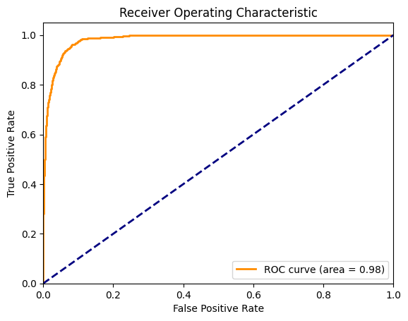

```python
plt.figure()
plt.plot(fpr, tpr, color='darkorange', lw=2, label='ROC curve (area = %0.2f)' % area)
plt.plot([0, 1], [0, 1], color='navy', lw=2, linestyle='--')
plt.xlim([0.0, 1.0])
plt.ylim([0.0, 1.05])
plt.xlabel('False Positive Rate')
plt.ylabel('True Positive Rate')
plt.title('Receiver Operating Characteristic')
plt.legend(loc="lower right")
plt.show()
```

## Model Evaluation : Rankordering, KS statistic, Gini coeff

```python
probabilities = best_model_logistic.predict_proba(X_test_encoded)[:,1]

df_eval = pd.DataFrame({
    'Default Truth': y_test,
    'Default Probability': probabilities
})
df_eval.head(3)
```

|  | Default Truth | Default Probability |
| --- | --- | --- |
| 19205 | 0 | 0.513 |
| 15514 | 0 | 0.000 |
| 30367 | 0 | 0.005 |

```python
df_eval['Decile'] = pd.qcut(df_eval['Default Probability'], 10, labels=False, duplicates='drop')
df_eval.head(3)
```

|  | Default Truth | Default Probability | Decile |
| --- | --- | --- | --- |
| 19205 | 0 | 0.513 | 8 |
| 15514 | 0 | 0.000 | 2 |
| 30367 | 0 | 0.005 | 6 |

```python
df_eval[df_eval.Decile==8]['Default Probability'].describe()
```

```
count   1250.000
mean       0.470
std        0.184
min        0.198
25%        0.300
50%        0.451
75%        0.626
max        0.812
Name: Default Probability, dtype: float64
```

```python
df_decile = df_eval.groupby('Decile').apply(lambda x: pd.Series({
    'Minimum Probability': x['Default Probability'].min(),
    'Maximum Probability': x['Default Probability'].max(),
    'Events': x['Default Truth'].sum(),
    'Non-events': x['Default Truth'].count() - x['Default Truth'].sum(),
}))
df_decile.reset_index(inplace=True)
df_decile
```

|  | Decile | Minimum Probability | Maximum Probability | Events | Non-events |
| --- | --- | --- | --- | --- | --- |
| 0 | 0 | 0.000 | 0.000 | 0.000 | 1250.000 |
| 1 | 1 | 0.000 | 0.000 | 0.000 | 1250.000 |
| 2 | 2 | 0.000 | 0.000 | 0.000 | 1249.000 |
| 3 | 3 | 0.000 | 0.000 | 0.000 | 1250.000 |
| 4 | 4 | 0.000 | 0.001 | 0.000 | 1250.000 |
| 5 | 5 | 0.001 | 0.004 | 0.000 | 1249.000 |
| 6 | 6 | 0.004 | 0.026 | 5.000 | 1245.000 |
| 7 | 7 | 0.026 | 0.198 | 10.000 | 1239.000 |
| 8 | 8 | 0.198 | 0.812 | 159.000 | 1091.000 |
| 9 | 9 | 0.812 | 1.000 | 900.000 | 350.000 |

```python
df_decile['Event Rate'] = df_decile['Events']*100 / (df_decile['Events']+df_decile['Non-events'])
df_decile['Non-event Rate'] = df_decile['Non-events']*100 / (df_decile['Events']+df_decile['Non-events'])
df_decile
```

|  | Decile | Minimum Probability | Maximum Probability | Events | Non-events | Event Rate | Non-event Rate |
| --- | --- | --- | --- | --- | --- | --- | --- |
| 0 | 0 | 0.000 | 0.000 | 0.000 | 1250.000 | 0.000 | 100.000 |
| 1 | 1 | 0.000 | 0.000 | 0.000 | 1250.000 | 0.000 | 100.000 |
| 2 | 2 | 0.000 | 0.000 | 0.000 | 1249.000 | 0.000 | 100.000 |
| 3 | 3 | 0.000 | 0.000 | 0.000 | 1250.000 | 0.000 | 100.000 |
| 4 | 4 | 0.000 | 0.001 | 0.000 | 1250.000 | 0.000 | 100.000 |
| 5 | 5 | 0.001 | 0.004 | 0.000 | 1249.000 | 0.000 | 100.000 |
| 6 | 6 | 0.004 | 0.026 | 5.000 | 1245.000 | 0.400 | 99.600 |
| 7 | 7 | 0.026 | 0.198 | 10.000 | 1239.000 | 0.801 | 99.199 |
| 8 | 8 | 0.198 | 0.812 | 159.000 | 1091.000 | 12.720 | 87.280 |
| 9 | 9 | 0.812 | 1.000 | 900.000 | 350.000 | 72.000 | 28.000 |

```python
df_decile = df_decile.sort_values(by='Decile', ascending=False).reset_index(drop=True)
df_decile
```

|  | Decile | Minimum Probability | Maximum Probability | Events | Non-events | Event Rate | Non-event Rate |
| --- | --- | --- | --- | --- | --- | --- | --- |
| 0 | 9 | 0.812 | 1.000 | 900.000 | 350.000 | 72.000 | 28.000 |
| 1 | 8 | 0.198 | 0.812 | 159.000 | 1091.000 | 12.720 | 87.280 |
| 2 | 7 | 0.026 | 0.198 | 10.000 | 1239.000 | 0.801 | 99.199 |
| 3 | 6 | 0.004 | 0.026 | 5.000 | 1245.000 | 0.400 | 99.600 |
| 4 | 5 | 0.001 | 0.004 | 0.000 | 1249.000 | 0.000 | 100.000 |
| 5 | 4 | 0.000 | 0.001 | 0.000 | 1250.000 | 0.000 | 100.000 |
| 6 | 3 | 0.000 | 0.000 | 0.000 | 1250.000 | 0.000 | 100.000 |
| 7 | 2 | 0.000 | 0.000 | 0.000 | 1249.000 | 0.000 | 100.000 |
| 8 | 1 | 0.000 | 0.000 | 0.000 | 1250.000 | 0.000 | 100.000 |
| 9 | 0 | 0.000 | 0.000 | 0.000 | 1250.000 | 0.000 | 100.000 |

```python
df_decile['Cum Events'] =  df_decile['Events'].cumsum()
df_decile['Cum Non-events'] =  df_decile['Non-events'].cumsum()
df_decile
```

|  | Decile | Minimum Probability | Maximum Probability | Events | Non-events | Event Rate | Non-event Rate | Cum Events | Cum Non-events |
| --- | --- | --- | --- | --- | --- | --- | --- | --- | --- |
| 0 | 9 | 0.812 | 1.000 | 900.000 | 350.000 | 72.000 | 28.000 | 900.000 | 350.000 |
| 1 | 8 | 0.198 | 0.812 | 159.000 | 1091.000 | 12.720 | 87.280 | 1059.000 | 1441.000 |
| 2 | 7 | 0.026 | 0.198 | 10.000 | 1239.000 | 0.801 | 99.199 | 1069.000 | 2680.000 |
| 3 | 6 | 0.004 | 0.026 | 5.000 | 1245.000 | 0.400 | 99.600 | 1074.000 | 3925.000 |
| 4 | 5 | 0.001 | 0.004 | 0.000 | 1249.000 | 0.000 | 100.000 | 1074.000 | 5174.000 |
| 5 | 4 | 0.000 | 0.001 | 0.000 | 1250.000 | 0.000 | 100.000 | 1074.000 | 6424.000 |
| 6 | 3 | 0.000 | 0.000 | 0.000 | 1250.000 | 0.000 | 100.000 | 1074.000 | 7674.000 |
| 7 | 2 | 0.000 | 0.000 | 0.000 | 1249.000 | 0.000 | 100.000 | 1074.000 | 8923.000 |
| 8 | 1 | 0.000 | 0.000 | 0.000 | 1250.000 | 0.000 | 100.000 | 1074.000 | 10173.000 |
| 9 | 0 | 0.000 | 0.000 | 0.000 | 1250.000 | 0.000 | 100.000 | 1074.000 | 11423.000 |

```python
df_decile['Cum Event Rate'] = df_decile['Cum Events'] * 100 / df_decile['Events'].sum()
df_decile['Cum Non-event Rate'] = df_decile['Cum Non-events']*100 / df_decile['Non-events'].sum()
df_decile
```

|  | Decile | Minimum Probability | Maximum Probability | Events | Non-events | Event Rate | Non-event Rate | Cum Events | Cum Non-events | Cum Event Rate | Cum Non-event Rate |
| --- | --- | --- | --- | --- | --- | --- | --- | --- | --- | --- | --- |
| 0 | 9 | 0.812 | 1.000 | 900.000 | 350.000 | 72.000 | 28.000 | 900.000 | 350.000 | 83.799 | 3.064 |
| 1 | 8 | 0.198 | 0.812 | 159.000 | 1091.000 | 12.720 | 87.280 | 1059.000 | 1441.000 | 98.603 | 12.615 |
| 2 | 7 | 0.026 | 0.198 | 10.000 | 1239.000 | 0.801 | 99.199 | 1069.000 | 2680.000 | 99.534 | 23.461 |
| 3 | 6 | 0.004 | 0.026 | 5.000 | 1245.000 | 0.400 | 99.600 | 1074.000 | 3925.000 | 100.000 | 34.361 |
| 4 | 5 | 0.001 | 0.004 | 0.000 | 1249.000 | 0.000 | 100.000 | 1074.000 | 5174.000 | 100.000 | 45.295 |
| 5 | 4 | 0.000 | 0.001 | 0.000 | 1250.000 | 0.000 | 100.000 | 1074.000 | 6424.000 | 100.000 | 56.237 |
| 6 | 3 | 0.000 | 0.000 | 0.000 | 1250.000 | 0.000 | 100.000 | 1074.000 | 7674.000 | 100.000 | 67.180 |
| 7 | 2 | 0.000 | 0.000 | 0.000 | 1249.000 | 0.000 | 100.000 | 1074.000 | 8923.000 | 100.000 | 78.114 |
| 8 | 1 | 0.000 | 0.000 | 0.000 | 1250.000 | 0.000 | 100.000 | 1074.000 | 10173.000 | 100.000 | 89.057 |
| 9 | 0 | 0.000 | 0.000 | 0.000 | 1250.000 | 0.000 | 100.000 | 1074.000 | 11423.000 | 100.000 | 100.000 |

```python
df_decile['KS'] = abs(df_decile['Cum Event Rate'] - df_decile['Cum Non-event Rate'])
df_decile
```

|  | Decile | Minimum Probability | Maximum Probability | Events | Non-events | Event Rate | Non-event Rate | Cum Events | Cum Non-events | Cum Event Rate | Cum Non-event Rate | KS |
| --- | --- | --- | --- | --- | --- | --- | --- | --- | --- | --- | --- | --- |
| 0 | 9 | 0.812 | 1.000 | 900.000 | 350.000 | 72.000 | 28.000 | 900.000 | 350.000 | 83.799 | 3.064 | 80.735 |
| 1 | 8 | 0.198 | 0.812 | 159.000 | 1091.000 | 12.720 | 87.280 | 1059.000 | 1441.000 | 98.603 | 12.615 | 85.988 |
| 2 | 7 | 0.026 | 0.198 | 10.000 | 1239.000 | 0.801 | 99.199 | 1069.000 | 2680.000 | 99.534 | 23.461 | 76.073 |
| 3 | 6 | 0.004 | 0.026 | 5.000 | 1245.000 | 0.400 | 99.600 | 1074.000 | 3925.000 | 100.000 | 34.361 | 65.639 |
| 4 | 5 | 0.001 | 0.004 | 0.000 | 1249.000 | 0.000 | 100.000 | 1074.000 | 5174.000 | 100.000 | 45.295 | 54.705 |
| 5 | 4 | 0.000 | 0.001 | 0.000 | 1250.000 | 0.000 | 100.000 | 1074.000 | 6424.000 | 100.000 | 56.237 | 43.763 |
| 6 | 3 | 0.000 | 0.000 | 0.000 | 1250.000 | 0.000 | 100.000 | 1074.000 | 7674.000 | 100.000 | 67.180 | 32.820 |
| 7 | 2 | 0.000 | 0.000 | 0.000 | 1249.000 | 0.000 | 100.000 | 1074.000 | 8923.000 | 100.000 | 78.114 | 21.886 |
| 8 | 1 | 0.000 | 0.000 | 0.000 | 1250.000 | 0.000 | 100.000 | 1074.000 | 10173.000 | 100.000 | 89.057 | 10.943 |
| 9 | 0 | 0.000 | 0.000 | 0.000 | 1250.000 | 0.000 | 100.000 | 1074.000 | 11423.000 | 100.000 | 100.000 | 0.000 |

To assess whether rank ordering is followed, we should look at whether higher deciles (those with higher predicted probabilities) have higher event rates compared to lower deciles. Rank ordering means that as you move from the top decile to the bottom decile, the event rate should generally decrease.

Non-Events - termed as good (customers) who do not default. Events - termed as bad (customers) who default.

Events and Non-Events terms are interchanged based on usecase to usecase.

eg: for marketing usecase, which customer to reach out (who will take loan based on offers) will be events - here it will termed as good, and the customers who will not take loans will be non-events (bad).

**Insights from the Decile Table**

1. Top Deciles
- The first decile (Decile 9) has a high event rate of 72.00% and a non-event rate of 28.00%. This indicates that the model is highly confident in predicting events in this decile.
- The second decile (Decile 8) also shows a significant event rate of 12.72%, with a cumulative event rate reaching 98.6%.
2. Middle Deciles:
- Deciles 7 and 6 show a significant drop in event rates
3. Lower Deciles:
- Deciles 5 to 0 show zero events, with all predictions being non-events. These deciles collectively have a non-event rate of 100%.
4. KS Statistic:
- The KS statistic, which is the maximum difference between cumulative event rates and cumulative non-event rates, is highest at Decile 8 with a value of 85.98%. This suggests that the model performs best at distinguishing between events and non-events up to this decile.
- The KS value gradually decreases in the following deciles, indicating a decrease in model performance for distinguishing between events and non-events.

**KS Value**

The highest KS value is 85.98%, found at Decile 8. This indicates that the model's performance in distinguishing between events and non-events is most significant at this decile. (If KS is in top 3 decile and score above 40, it is considered a good predictive model.)

```python
gini_coefficient = 2 * area - 1

print("AUC:", area)
print("Gini Coefficient:", gini_coefficient)
```

```
AUC: 0.9836544617176851
Gini Coefficient: 0.9673089234353702
```

AUC of 0.98: The model is very good at distinguishing between events and non-events.

Gini coefficient of 0.96: This further confirms that the model is highly effective in its predictions, with almost perfect rank ordering capability.

The Gini coefficient ranges from -1 to 1, where a value closer to 1 signifies a perfect model, 0 indicates a model with no discriminative power, and -1 signifies a perfectly incorrect model.

#### Finalize The Model and Visualize Feature Importance

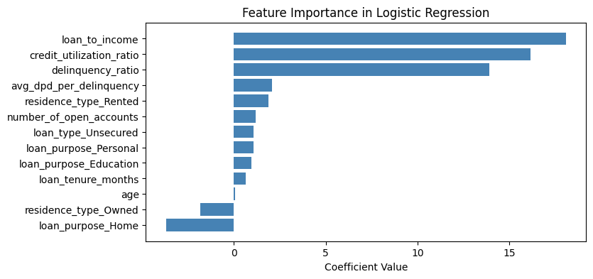

```python
final_model = best_model_logistic

feature_importance = final_model.coef_[0]

# Create a DataFrame for easier handling
coef_df = pd.DataFrame(feature_importance, index=X_train_encoded.columns, columns=['Coefficients'])

# Sort the coefficients for better visualization
coef_df = coef_df.sort_values(by='Coefficients', ascending=True)

# Plotting
plt.figure(figsize=(8, 4))
plt.barh(coef_df.index, coef_df['Coefficients'], color='steelblue')
plt.xlabel('Coefficient Value')
plt.title('Feature Importance in Logistic Regression')
plt.show()
```

### Save the Model

```python
X_test_encoded.head(2)
```

|  | age | loan_tenure_months | number_of_open_accounts | credit_utilization_ratio | loan_to_income | delinquency_ratio | avg_dpd_per_delinquency | residence_type_Owned | residence_type_Rented | loan_purpose_Education | loan_purpose_Home | loan_purpose_Personal | loan_type_Unsecured |
| --- | --- | --- | --- | --- | --- | --- | --- | --- | --- | --- | --- | --- | --- |
| 19205 | 0.346 | 0.755 | 0.333 | 0.990 | 0.550 | 0.000 | 0.000 | True | False | False | True | False | False |
| 15514 | 0.481 | 0.226 | 1.000 | 0.323 | 0.220 | 0.000 | 0.000 | True | False | True | False | False | False |

```python
X_test_encoded.columns
```

```
Index(['age', 'loan_tenure_months', 'number_of_open_accounts',
       'credit_utilization_ratio', 'loan_to_income', 'delinquency_ratio',
       'avg_dpd_per_delinquency', 'residence_type_Owned',
       'residence_type_Rented', 'loan_purpose_Education', 'loan_purpose_Home',
       'loan_purpose_Personal', 'loan_type_Unsecured'],
      dtype='object')
```

```python
cols_to_scale
```

```
Index(['age', 'number_of_dependants', 'years_at_current_address', 'zipcode',
       'sanction_amount', 'processing_fee', 'gst', 'net_disbursement',
       'loan_tenure_months', 'principal_outstanding',
       'bank_balance_at_application', 'number_of_open_accounts',
       'number_of_closed_accounts', 'enquiry_count',
       'credit_utilization_ratio', 'loan_to_income', 'delinquency_ratio',
       'avg_dpd_per_delinquency'],
      dtype='object')
```

```python
X_train_encoded.columns
```

```
Index(['age', 'loan_tenure_months', 'number_of_open_accounts',
       'credit_utilization_ratio', 'loan_to_income', 'delinquency_ratio',
       'avg_dpd_per_delinquency', 'residence_type_Owned',
       'residence_type_Rented', 'loan_purpose_Education', 'loan_purpose_Home',
       'loan_purpose_Personal', 'loan_type_Unsecured'],
      dtype='object')
```

```python
from joblib import dump

model_data = {
    'model': final_model,
    'features': X_train_encoded.columns,
    'scaler': scaler,
    'cols_to_scale': cols_to_scale
}
dump(model_data, 'artifacts/model_data.joblib')
```

```
['artifacts/model_data.joblib']
```

```python
final_model.coef_, final_model.intercept_
```

```
(array([[ 0.05741907,  0.64234004,  1.17192647, 16.17515666, 18.10168487,
         13.9318573 ,  2.07903646, -1.8319094 ,  1.89447319,  0.95512063,
         -3.70061271,  1.08588959,  1.08588959]]),
 array([-21.28353025]))
```